# Tutorial 5: Predicting Distillation Product Purity Using Polynomial Regression and Regularisation

CHEE4003: Special Topics A - Artificial Intelligence in Chemical Engineering

Published

October 8, 2026

# Polynomial Regression

In Tutorial 4, we explored simple and multivariate linear regression. In a linear regression model, each feature is multiplied by a coefficient and combined to predict the target variable. With a single feature, this relationship is represented by a straight line; with multiple features, the model defines a hyperplane in the feature space. Polynomial regression extends this idea by creating new features from powers of the original variables. The degree of the polynomial therefore becomes a **hyperparameter** that controls the flexibility of the model.

In this tutorial, we will explore **polynomial regression** and **regularisation** using data from a **binary distillation column**. The column operates continuously at steady state and is used to separate a more volatile component from a liquid mixture. One of the most important operating variables is the **reflux ratio ($R$)**, which determines how much condensed liquid is returned to the top of the column, as shown in Figure 1.

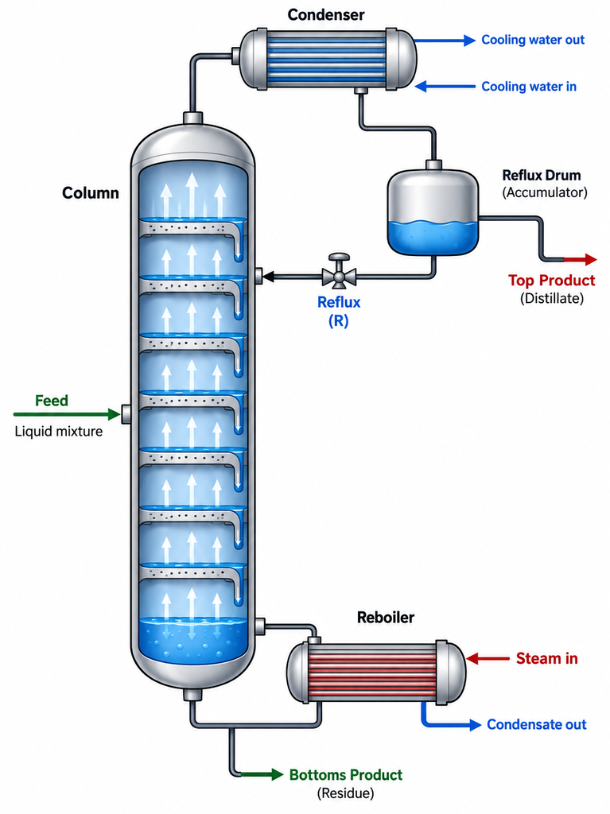

Figure 1: Binary distillation column showing the reflux stream used to control top-product purity.

In industrial distillation, engineers must balance **product quality** against **energy consumption**. Increasing the **reflux ratio ($R$)** generally improves separation by increasing contact between the rising vapour and descending liquid phases, leading to higher top-product purity. However, the improvement becomes progressively smaller at higher reflux ratios, while condenser and reboiler duties continue to increase, resulting in higher operating costs. Predictive models relating reflux ratio to product purity can therefore be used to estimate column performance, support process optimisation, and help operators maintain product specifications while minimising energy usage.

To investigate how operating conditions affect separation performance, engineers conducted **120 experimental runs** across a range of reflux ratios. For each run, the **reflux ratio** and the resulting **top-product purity (%)** were recorded. Our goal is to develop a predictive model that estimates product purity from operating conditions.

Download the dataset to get started:

```
distillation_reflux_purity.csv
```

```
R,Purity
2.201172080943062,61.71485765271682
3.1652375689823216,64.19210961624152
1.2796296884628802,59.939229564463076
4.776650019955069,66.65961117822658
... (117 more lines)
```

Below is a description of each of the variables in the dataset:

| Column | Description |
| --- | --- |
| R | Reflux ratio, defined as the ratio $(R = \frac{L}{D})$ of liquid returned to the column $(L)$ as reflux to the distillate $(D)$ withdrawn [unitless] |
| Purity | Top-product purity [%] (**target variable**) |

Before anything else, we need to have the correct libraries imported. Copy the following code into your script to import the necessary libraries:

```
import_libraries.py
```

```python
import numpy as np
import pandas as pd
import matplotlib.pyplot as plt
from sklearn.model_selection import train_test_split, cross_val_score
from sklearn.linear_model import LinearRegression, Ridge, Lasso, ElasticNet
from sklearn.preprocessing import PolynomialFeatures, StandardScaler
from sklearn.pipeline import make_pipeline
from sklearn.metrics import mean_absolute_error, mean_squared_error, r2_score
```

## Part A: Fitting a Curve and Model Complexity

Every model in Tutorial 4 was built from a weighted sum of the original features, resulting in a linear combination of the inputs used to predict the target. This is a strong assumption because it implies that the effect of a variable is constant across its entire operating range. In reality, most chemical processes do not behave this way. For example, increasing the reflux ratio in a distillation column may produce substantial improvements in product purity at low values of $R$, while the same increase at higher values produces much smaller gains. Capturing this type of behaviour requires a more flexible model than a purely linear relationship, which motivates the use of **polynomial regression**.

**NoteWhat is polynomial regression?**

Polynomial regression extends linear regression by including powers of the original feature as additional predictors. For a single feature $x$, the model takes the form
$$\hat{y} = w_0 + w_1x + w_2x^2 + \cdots + w_dx^d$$
where $d$ is the **polynomial degree**.

Although the resulting model can represent curved relationships, the fitting procedure is exactly the same as in Tutorial 4. Once the transformed features $x$, $x^2$, $\ldots$, $x^d$ have been created, the problem becomes a standard multiple linear regression problem and the same closed-form least-squares solution applies.

To see why, we can define a new set of features:

$$z_1 = x,\qquad z_2 = x^2,\qquad \ldots,\qquad z_d = x^d.$$

The polynomial model can then be written as

$$\hat{y} = w_0 + w_1z_1 + w_2z_2 + \cdots + w_dz_d,$$

which has exactly the **same form** as a **multiple linear regression** model. This is why polynomial regression is still considered a **linear model**: it is linear in both the transformed features $z_i$ and the **parameters** $w_0, w_1, \ldots, w_d$. The model produces a curved relationship only because the transformed features themselves are nonlinear functions of the original variable $x$.

### Task 1 : Load the dataset

Write a function `load_distillation_data` that loads the dataset and returns the feature `X` (the reflux ratio) and the target `y` (the purity). Keep `X` as a DataFrame rather than a Series.

```
load_distillation_data.py
```

```python
def load_distillation_data(file_path):
    """
    Load the distillation dataset and return the feature and target.

    Parameters
    ----------
    file_path : str
        Path to the CSV file.

    Returns
    -------
    X : pd.DataFrame
        Single-column DataFrame containing the reflux ratio.
    y : pd.Series
        Series containing the top-product purity.
    """
```

When you run this function, it should yield the following output:

X, y = load_distillation_data('data/distillation_reflux_purity.csv')

Features shape: (120, 1)

Target shape: (120,)

Reflux ratio ranges from 0.50 to 5.00

**Callout-answer**Answer**

```
load_distillation_data.py
```

```python
def load_distillation_data(file_path):
    """
    Load the distillation dataset and return the feature and target.

    Parameters
    ----------
    file_path : str
        Path to the CSV file.

    Returns
    -------
    X : pd.DataFrame
        Single-column DataFrame containing the reflux ratio.
    y : pd.Series
        Series containing the top-product purity.
    """

    # Load the dataset (utf-8-sig strips the byte-order mark on the first column)
    data = pd.read_csv(file_path, encoding="utf-8-sig")

    # Double brackets keep X as a 2D DataFrame, which is what scikit-learn expects
    X = data[["R"]]
    y = data["Purity"]

    print(f"Features shape: {X.shape}")
    print(f"Target shape:   {y.shape}")
    print(f"Reflux ratio ranges from {X['R'].min():.2f} to {X['R'].max():.2f}")
    return X, y

X, y = load_distillation_data('data/distillation_reflux_purity.csv')
```

Output

```
Features shape: (120, 1)
Target shape:   (120,)
Reflux ratio ranges from 0.50 to 5.00
```

### Task 2 : Look at the shape of the data

Before fitting any models, it is important to understand what the data look like. With only a single feature, we can visualise the entire dataset on a single set of axes, making it easy to identify trends, patterns, and potential nonlinear behaviour. Write a function `plot_purity_vs_reflux` that creates a scatter plot of top-product purity against reflux ratio.

```
plot_purity_vs_reflux.py
```

```python
def plot_purity_vs_reflux(X, y):
    """
    Scatter the distillate purity against the reflux ratio.

    Parameters
    ----------
    X : pd.DataFrame
        The feature DataFrame containing the reflux ratio.
    y : pd.Series
        The target (purity).

    Returns
    -------
    None
        Displays a scatter plot of distillate purity against reflux ratio.
    """
```

plot_purity_vs_reflux(X, y)

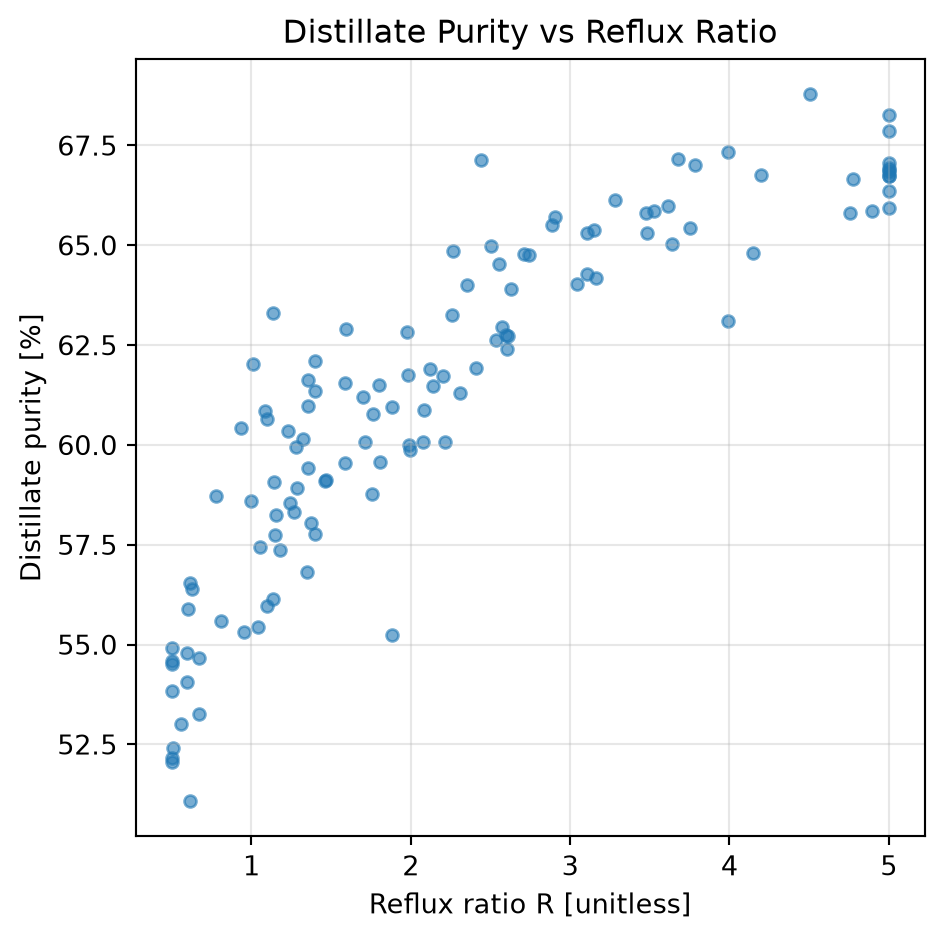

Purity increases rapidly at low reflux ratios, but the rate of improvement decreases as the reflux ratio becomes larger. Should this behaviour be expected?

**Callout-answer**Answer**

```
plot_purity_vs_reflux.py
```

```python
def plot_purity_vs_reflux(X, y):
    """
    Scatter the distillate purity against the reflux ratio.

    Parameters
    ----------
    X : pd.DataFrame
        The feature DataFrame containing the reflux ratio.
    y : pd.Series
        The target (purity).

    Returns
    -------
    None
        Displays a scatter plot of distillate purity against reflux ratio.
    """
    plt.figure(figsize=(5, 5))
    plt.scatter(X["R"], y, alpha=0.6, s=20)
    plt.xlabel("Reflux ratio R [unitless]")
    plt.ylabel("Distillate purity [%]")
    plt.title("Distillate Purity vs Reflux Ratio")
    plt.grid(True, alpha=0.3)
    plt.tight_layout()
    plt.show()

plot_purity_vs_reflux(X, y)
```

Output

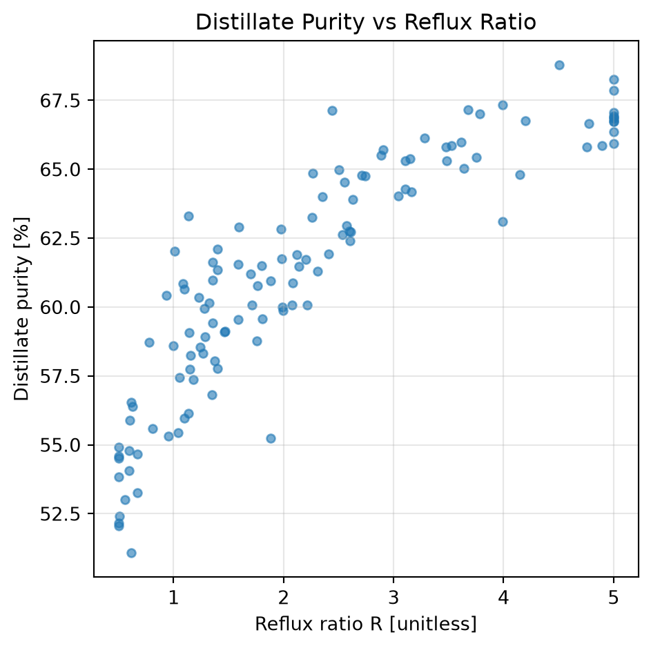

This is the expected behaviour of a distillation column. Increasing the reflux ratio improves separation and therefore increases top-product purity. However, as the column approaches its separation limit, each additional increase in reflux produces progressively smaller gains in purity, resulting in **diminishing returns**. This suggests that the relationship between reflux ratio and purity is unlikely to be a straight line.

### Task 3 : Split into training and testing sets

As in Tutorial 4, we will use an **80/20 train-test split**, with 80% of the data used for training and 20% reserved for testing. To ensure that all models are evaluated on the same samples throughout this tutorial, use a `test_size` of `0.2` and a `random_state` of `42`.

This is exactly the same `preprocess_data` function you wrote in Tutorial 4, so bring it across unchanged and use it to divide the reflux-ratio data into training and testing sets.

X_train, X_test, y_train, y_test = preprocess_data(X, y)

X_train.shape, X_test.shape, y_train.shape, y_test.shape

((96, 1), (24, 1), (96,), (24,))

**Callout-answer**Answer**

```
preprocess_data.py
```

```python
def preprocess_data(X, y, test_size=0.2, random_state=42):
    """
    Split the features and target into training and testing sets.

    Parameters
    ----------
    X : pd.DataFrame
        The feature DataFrame.
    y : pd.Series
        The target.
    test_size : float, optional
        The proportion of the data to hold back for testing (default is 0.2).
    random_state : int, optional
        The random seed for reproducibility (default is 42).

    Returns
    -------
    X_train, X_test, y_train, y_test
        The training and testing features and targets.
    """
    X_train, X_test, y_train, y_test = train_test_split(
        X, y, test_size=test_size, random_state=random_state)
    return X_train, X_test, y_train, y_test

X_train, X_test, y_train, y_test = preprocess_data(X, y)
print(X_train.shape, X_test.shape, y_train.shape, y_test.shape)
```

Output

```
(96, 1) (24, 1) (96,) (24,)
```

### Task 4 : Build a polynomial model

We will now extend linear regression by creating polynomial features, allowing the model to fit curved relationships while still using the same underlying fitting procedure.

Write a function `build_polynomial_model` that takes a polynomial degree and returns an **unfitted** three-step pipeline consisting of:

1. `PolynomialFeatures` to generate powers of the original feature,
2. `StandardScaler` to place those features on a common scale, and
3. `LinearRegression` to perform the final fit.

Once the function has been written, build a **degree-3** polynomial model.

**TipBuilding the powers, and chaining the steps**

`PolynomialFeatures(degree=3, include_bias=False)` is a **transformer** that converts a single feature $R$ into the features

$$R,\quad R^2,\quad R^3.$$

These additional features allow the model to fit curved relationships rather than being restricted to a straight line. Setting `include_bias=False` prevents `PolynomialFeatures` from adding a column of ones, since `LinearRegression()` already fits an intercept term.

Rather than creating the polynomial features manually and passing them to the model, chain the steps together using

```python
make_pipeline(step1, step2, step3)
```

The resulting pipeline behaves like a single model: calling `.fit()` generates the polynomial features, scales them, and fits the regression model, while calling `.predict()` automatically applies the same transformations to new data before making predictions. See the documentation for more details: [PolynomialFeatures](https://scikit-learn.org/stable/modules/generated/sklearn.preprocessing.PolynomialFeatures.html) and [make_pipeline](https://scikit-learn.org/stable/modules/generated/sklearn.pipeline.make_pipeline.html).

```
build_polynomial_model.py
```

```python
def build_polynomial_model(degree):
    """
    Build an unfitted polynomial regression pipeline.

    Parameters
    ----------
    degree : int
        The highest power of the feature to include.

    Returns
    -------
    model : Pipeline
        An unfitted pipeline of PolynomialFeatures, StandardScaler and LinearRegression.
    """
```

**NoteWhy standardise the powers?**

When you run this, it should yield the following output:

poly_model = build_polynomial_model(degree=3)

poly_model.fit(X_train, y_train)

Pipeline(steps=[('polynomialfeatures',

PolynomialFeatures(degree=3, include_bias=False)),

('standardscaler', StandardScaler()),

('linearregression', LinearRegression())])

lr = poly_model[-1]

print(f"Intercept (w0): {lr.intercept_:.3f}")

Intercept (w0): 61.394

for i, coef in enumerate(lr.coef_, start=1):

print(f"w{i}: {coef:.3f}")

w1: 12.918

w2: -13.156

w3: 4.233

Because the polynomial features are standardised before fitting, these coefficients correspond to the **scaled polynomial features** rather than directly to $R$, $R^2$, and $R^3$. The coefficient values therefore indicate the relative importance of the terms but do not represent the polynomial equation in the original reflux-ratio units.

**TipReaching inside a pipeline**

A pipeline can be indexed like a list, so `model[-1]` gives you the last step and `model[-1].coef_` gives you its coefficients.

The fitted polynomial contains both positive and negative coefficients. What do the signs of the coefficients suggest about the shape of the fitted curve?

**Callout-answer**Answer**

```
build_polynomial_model.py
```

```python
def build_polynomial_model(degree):
    """
    Build an unfitted polynomial regression pipeline.

    Parameters
    ----------
    degree : int
        The highest power of the feature to include.

    Returns
    -------
    model : Pipeline
        An unfitted pipeline of PolynomialFeatures, StandardScaler and LinearRegression.
    """
    model = make_pipeline(
        PolynomialFeatures(degree=degree, include_bias=False),
        StandardScaler(),
        LinearRegression(),
    )
    return model

poly_model = build_polynomial_model(degree=3)
poly_model.fit(X_train, y_train)

# Extract the fitted regression model (last step in the pipeline)
lr = poly_model[-1]

# Print the intercept and polynomial coefficients
print(f"Intercept (w0): {lr.intercept_:.3f}")
for i, coef in enumerate(lr.coef_, start=1):
    print(f"w{i}: {coef:.3f}")
```

Output

```
Intercept (w0): 61.394
w1: 12.918
w2: -13.156
w3: 4.233
```

Unlike a linear model, the polynomial model includes higher-order terms, allowing the fitted curve to change slope across the operating range. The mixture of positive and negative coefficients indicates that the relationship is not constrained to a straight line and can capture more complex, curved behaviour.

### Task 5 : Plot the fitted curves

Although a degree-3 polynomial regression model has been fitted, it is not yet clear whether this is the most appropriate level of model complexity. Before selecting an appropriate polynomial degree, it is useful to examine how models of different complexity fit the training data. In this task, you will compare polynomial regression models with degrees 1, 3, and 15 by plotting their fitted curves.

Write a function `plot_fitted_curves` that accepts a dictionary of `{label: fitted_model}`, displays the training data as a scatter plot, and overlays the predictions from each fitted model across the range of reflux ratios (`R`).

Because the models are implemented as pipelines that expect a DataFrame containing a column named `R`, construct the prediction grid as

```python
pd.DataFrame({"R": np.linspace(...)})
```

rather than as a NumPy array.

```
plot_fitted_curves.py
```

```python
def plot_fitted_curves(models, X, y, title):
    """
    Scatter the data and overlay the prediction curve of each fitted model.

    Parameters
    ----------
    models : dict
        A mapping of {label: fitted model}, one curve per entry.
    X : pd.DataFrame
        The features to scatter and to set the range of the plotting grid.
    y : pd.Series
        The target to scatter.
    title : str
        The plot title.
    """
```

models = {

"Degree 1 (straight line)": build_polynomial_model(1).fit(X_train, y_train),

"Degree 3": build_polynomial_model(3).fit(X_train, y_train),

"Degree 15": build_polynomial_model(15).fit(X_train, y_train),

}

plot_fitted_curves(models, X_train, y_train, "Polynomial Fits of Increasing Degree")

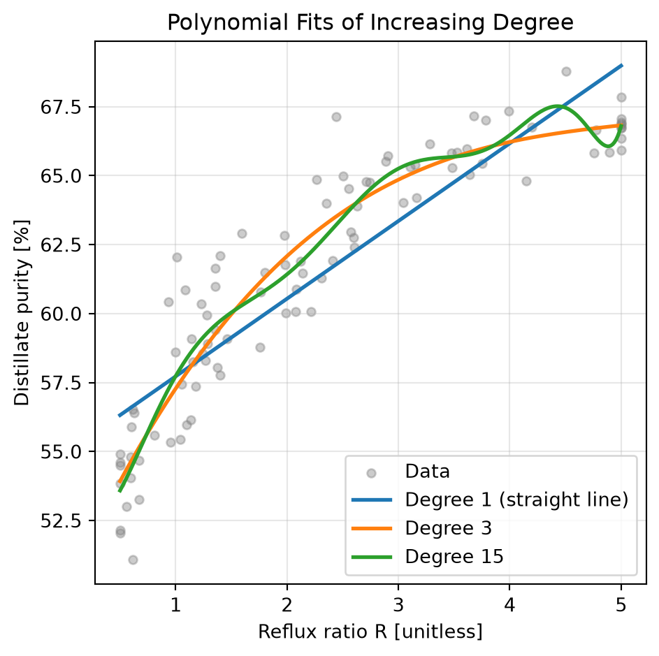

Is **degree** a hyperparameter? What value would you pick based on the curves?

**Callout-answer**Answer**

```
plot_fitted_curves.py
```

```python
def plot_fitted_curves(models, X, y, title):
    """
    Scatter the data and overlay the prediction curve of each fitted model.

    Parameters
    ----------
    models : dict
        A mapping of {label: fitted model}, one curve per entry.
    X : pd.DataFrame
        The features to scatter and to set the range of the plotting grid.
    y : pd.Series
        The target to scatter.
    title : str
        The plot title.
    """
    plt.figure(figsize=(5, 5))
    plt.scatter(X["R"], y, alpha=0.4, s=20, color="grey", label="Data")

    # A fine grid of reflux ratios to draw each fitted curve over
    R_grid = pd.DataFrame({"R": np.linspace(X["R"].min(), X["R"].max(), 300)})
    for label, model in models.items():
        plt.plot(R_grid["R"], model.predict(R_grid), linewidth=2, label=label)

    plt.xlabel("Reflux ratio R [unitless]")
    plt.ylabel("Distillate purity [%]")
    plt.title(title)
    plt.legend()
    plt.grid(True, alpha=0.3)
    plt.tight_layout()
    plt.show()

models = {
    "Degree 1 (straight line)": build_polynomial_model(1).fit(X_train, y_train),
    "Degree 3": build_polynomial_model(3).fit(X_train, y_train),
    "Degree 15": build_polynomial_model(15).fit(X_train, y_train),
}
plot_fitted_curves(models, X_train, y_train, "Polynomial Fits of Increasing Degree")
```

Output

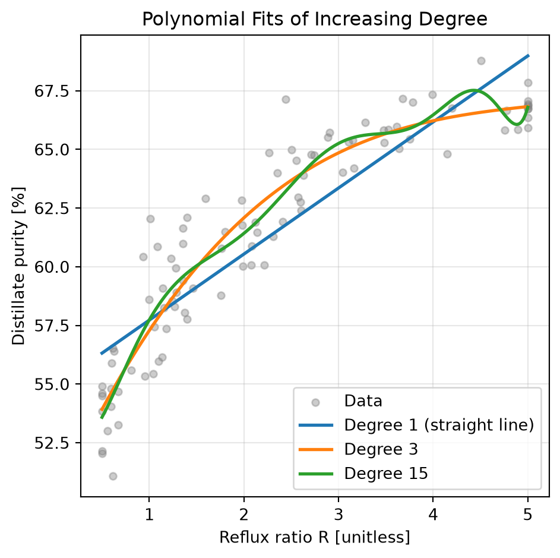

The polynomial **degree** is a hyperparameter because it controls the model’s complexity and is chosen before training.

Based on the curves, **degree 3** appears to be the best choice. The degree-1 model underfits the data, while the degree-15 model shows signs of overfitting. The degree-3 model captures the overall trend without introducing unnecessary oscillations. However, visual inspection alone is not sufficient to determine the optimal degree.

### Task 6 : Choose the degree

Eyeballing curves is not sufficient justification for a polynomial model degree choice. Write a function `plot_degree_sweep` that loops over degrees 1 to 15 and, for each one, records two numbers: the RMSE on the training data the model was fitted to, and the cross-validated RMSE from 5-fold cross-validation on the training set. Plot both against degree, and use the result to pick the degree.

**TipGetting an RMSE out of `cross_val_score`**

Recall that the `cross_validate_model()` function written in Tutorial 4 uses `cross_val_score()` to estimate model performance across multiple folds. Review that implementation and adapt the same approach here to compute the 5-fold cross-validated RMSE for each polynomial degree.

Note that `cross_val_score()` is designed to **maximise** its scoring metric, so error measures are provided in negated form. For example, `scoring="neg_root_mean_squared_error"` returns an array of *negative* RMSE values, where less negative is better. To obtain the RMSE, flip the sign when reporting the result, for example with `-scores.mean()`. The same convention applies to `"neg_mean_absolute_error"` and `"neg_mean_squared_error"`. A full list of scoring options is available in the [scoring parameter documentation](https://scikit-learn.org/stable/modules/model_evaluation.html#scoring-parameter).

```
plot_degree_sweep.py
```

```python
def plot_degree_sweep(X_train, y_train, max_degree=15):
    """
    Compare training and cross-validated error across polynomial degrees.

    Parameters
    ----------
    X_train : pd.DataFrame
        The training features.
    y_train : pd.Series
        The training target.
    max_degree : int, optional
        The highest degree to try (default is 15).

    Returns
    -------
    degrees, train_rmse, cv_rmse : list
        The degrees tried and the corresponding errors.
    """
    return degrees, train_rmse, cv_rmse
```

Based on the training and cross-validated RMSE curves, which polynomial degree would you select for the final model, and why?

degrees, train_rmse, cv_rmse = plot_degree_sweep(X_train, y_train, max_degree=15)

Degree 1: train RMSE = 2.078 CV RMSE = 2.092

Degree 2: train RMSE = 1.485 CV RMSE = 1.478

Degree 3: train RMSE = 1.469 CV RMSE = 1.479

Degree 4: train RMSE = 1.451 CV RMSE = 1.494

Degree 5: train RMSE = 1.440 CV RMSE = 1.498

Degree 6: train RMSE = 1.439 CV RMSE = 1.505

Degree 7: train RMSE = 1.436 CV RMSE = 1.511

Degree 8: train RMSE = 1.437 CV RMSE = 1.514

Degree 9: train RMSE = 1.419 CV RMSE = 1.500

Degree 10: train RMSE = 1.419 CV RMSE = 1.496

Degree 11: train RMSE = 1.419 CV RMSE = 1.494

Degree 12: train RMSE = 1.419 CV RMSE = 1.496

Degree 13: train RMSE = 1.419 CV RMSE = 1.537

Degree 14: train RMSE = 1.419 CV RMSE = 1.539

Degree 15: train RMSE = 1.419 CV RMSE = 1.540

best_degree = degrees[np.argmin(cv_rmse)]

print(f"Best degree by cross-validation: {best_degree}")

Best degree by cross-validation: 2

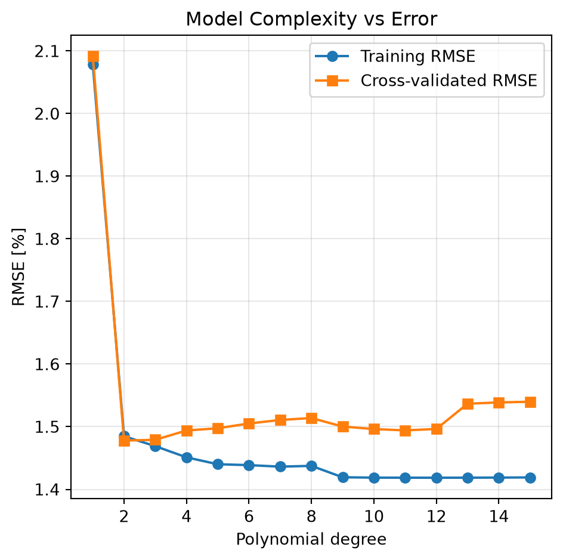

**Callout-answer**Answer**

```
plot_degree_sweep.py
```

```python
def plot_degree_sweep(X_train, y_train, max_degree=15):
    """
    Compare training and cross-validated error across polynomial degrees.

    Parameters
    ----------
    X_train : pd.DataFrame
        The training features.
    y_train : pd.Series
        The training target.
    max_degree : int, optional
        The highest degree to try (default is 15).

    Returns
    -------
    degrees, train_rmse, cv_rmse : list
        The degrees tried and the corresponding errors.
    """
    degrees = list(range(1, max_degree + 1))
    train_rmse, cv_rmse = [], []

    for degree in degrees:
        model = build_polynomial_model(degree)

        # Cross-validate first, while the pipeline is still unfitted
        scores = cross_val_score(model, X_train, y_train, cv=5, scoring="neg_root_mean_squared_error")
        cv_rmse.append(-scores.mean())

        # Then fit on the whole training set to get the training error
        model.fit(X_train, y_train)
        train_rmse.append(np.sqrt(mean_squared_error(y_train, model.predict(X_train))))

        print(f"Degree {degree:2d}:  train RMSE = {train_rmse[-1]:.3f}   CV RMSE = {cv_rmse[-1]:.3f}")

    plt.figure(figsize=(5, 5))
    plt.plot(degrees, train_rmse, "o-", label="Training RMSE")
    plt.plot(degrees, cv_rmse, "s-", label="Cross-validated RMSE")
    plt.xlabel("Polynomial degree")
    plt.ylabel("RMSE [%]")
    plt.title("Model Complexity vs Error")
    plt.legend()
    plt.grid(True, alpha=0.3)
    plt.tight_layout()
    plt.show()
    return degrees, train_rmse, cv_rmse

degrees, train_rmse, cv_rmse = plot_degree_sweep(X_train, y_train, max_degree=15)
best_degree = degrees[np.argmin(cv_rmse)]
print(f"Best degree by cross-validation: {best_degree}")
```

Output

```
Degree  1:  train RMSE = 2.078   CV RMSE = 2.092
Degree  2:  train RMSE = 1.485   CV RMSE = 1.478
Degree  3:  train RMSE = 1.469   CV RMSE = 1.479
Degree  4:  train RMSE = 1.451   CV RMSE = 1.494
Degree  5:  train RMSE = 1.440   CV RMSE = 1.498
Degree  6:  train RMSE = 1.439   CV RMSE = 1.505
Degree  7:  train RMSE = 1.436   CV RMSE = 1.511
Degree  8:  train RMSE = 1.437   CV RMSE = 1.514
Degree  9:  train RMSE = 1.419   CV RMSE = 1.500
Degree 10:  train RMSE = 1.419   CV RMSE = 1.496
Degree 11:  train RMSE = 1.419   CV RMSE = 1.494
Degree 12:  train RMSE = 1.419   CV RMSE = 1.496
Degree 13:  train RMSE = 1.419   CV RMSE = 1.537
Degree 14:  train RMSE = 1.419   CV RMSE = 1.539
Degree 15:  train RMSE = 1.419   CV RMSE = 1.540
```

Output

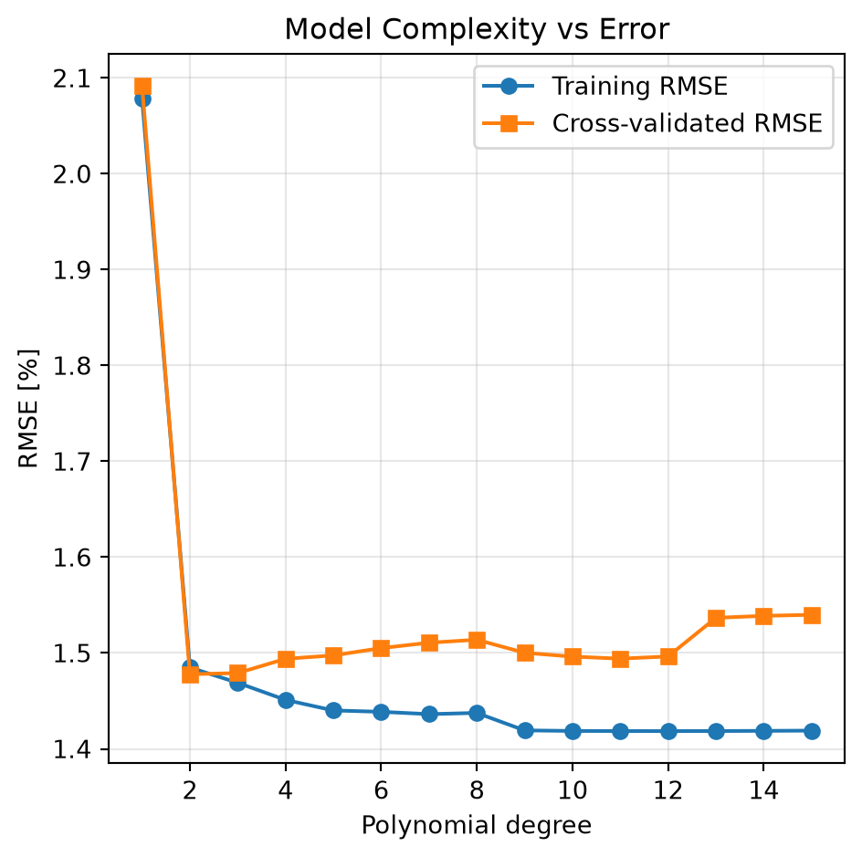

Output

```
Best degree by cross-validation: 2
```

The cross-validated RMSE is minimised at **degree 2**, indicating that it provides the best predictive performance on unseen data. Although the degree-3 model achieves a very similar cross-validated RMSE, the improvement is negligible and does not justify the additional complexity.

### Task 7 :Performance evaluation and residual analysis

Using the `build_polynomial_model()` function, build a polynomial regression model using the optimal polynomial degree, `best_degree`, identified in the previous analysis. Then, use the `fit()` method to train the model on the training data. Finally, reuse the `evaluate_regression()` function from Tutorial 4 to assess the performance of the polynomial regression model on the testing set. Report the **MAE**, **MSE**, **RMSE**, and **$R^2$** values.

final_poly_model = build_polynomial_model(degree=best_degree)

final_poly_model.fit(X_train, y_train)

Pipeline(steps=[('polynomialfeatures', PolynomialFeatures(include_bias=False)),

('standardscaler', StandardScaler()),

('linearregression', LinearRegression())])

final_poly_metrics = evaluate_regression(final_poly_model, X_test, y_test)

MAE: 1.768

MSE: 5.308

RMSE: 2.304

R2: 0.450

What does this result tell you about the model’s performance?

**Callout-answer**Answer**

```
evaluate_regression.py
```

```python
def evaluate_regression(model, X_test, y_test):
    """
    Evaluate a regression model on the test set using
    common regression metrics.

    Parameters
    ----------
    model : fitted regression model
        The trained model to evaluate.
    X_test : pd.DataFrame
        Test features.
    y_test : pd.Series
        True target values for the test set.

    Returns
    -------
    mae : float
        Mean Absolute Error.
    mse : float
        Mean Squared Error.
    rmse : float
        Root Mean Squared Error.
    r2 : float
        Coefficient of determination (R²).
    """
    y_pred = model.predict(X_test)
    mae = mean_absolute_error(y_test, y_pred)
    mse = mean_squared_error(y_test, y_pred)
    rmse = np.sqrt(mse)
    r2 = r2_score(y_test, y_pred)
    print(f"MAE:  {mae:.3f}")
    print(f"MSE:  {mse:.3f}")
    print(f"RMSE: {rmse:.3f}")
    print(f"R2:   {r2:.3f}")
    return mae, mse, rmse, r2

final_poly_model = build_polynomial_model(degree=best_degree)
final_poly_model.fit(X_train, y_train)
final_poly_metrics = evaluate_regression(final_poly_model, X_test, y_test)
```

Output

```
MAE:  1.768
MSE:  5.308
RMSE: 2.304
R2:   0.450
```

An $R^2$ value of 0.450 indicates that the model explains approximately 45.0% of the variation in top-product purity. The **MAE** of 1.768 and **RMSE** of 2.304 suggest that the model’s predictions are typically within about 2 purity units of the observed values. While the model captures some of the relationship between reflux ratio and purity, more than half of the variation remains unexplained. These results suggest that reflux ratio alone does not fully explain the variation in top-product purity. Additional process variables or more informative features may be needed to substantially improve predictive performance.

Finally, reuse the `plot_residuals()` function from Tutorial 4 to inspect the residual plot.

plot_residuals(final_poly_model, X_test, y_test, "Residual Plot: Polynomial Regression (Degree 2)")

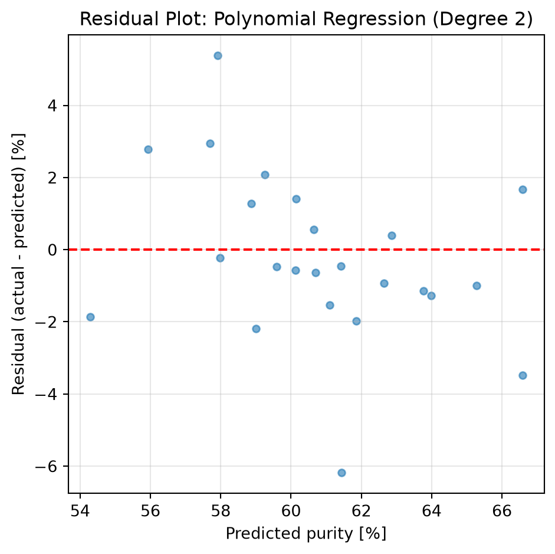

Are the residuals randomly distributed around zero, or do they show a clear pattern? What does this indicate about the quality of the model fit?

**Callout-answer**Answer**

```
plot_residuals.py
```

```python
def plot_residuals(model, X, y, title="Residual Plot"):
    """
    Plot residuals (actual minus predicted) against the
    predicted values for the test set.

    Parameters
    ----------
    model : fitted regression model
        The trained model to evaluate.
    X_test : pd.DataFrame
        Test features.
    y_test : pd.Series
        True target values for the test set.

    Returns
    -------
    None
        Displays a residual plot.
    """
    y_pred = model.predict(X)
    residuals = y - y_pred

    plt.figure(figsize=(5, 5))
    plt.scatter(y_pred, residuals, alpha=0.6, s=20)
    plt.axhline(0, color="red", linestyle="--")
    plt.xlabel("Predicted purity [%]")
    plt.ylabel("Residual (actual - predicted) [%]")
    plt.title(title)
    plt.grid(True, alpha=0.3)
    plt.tight_layout()
    plt.show()

plot_residuals(final_poly_model, X_test, y_test, "Residual Plot: Polynomial Regression (Degree 2)")
```

Output

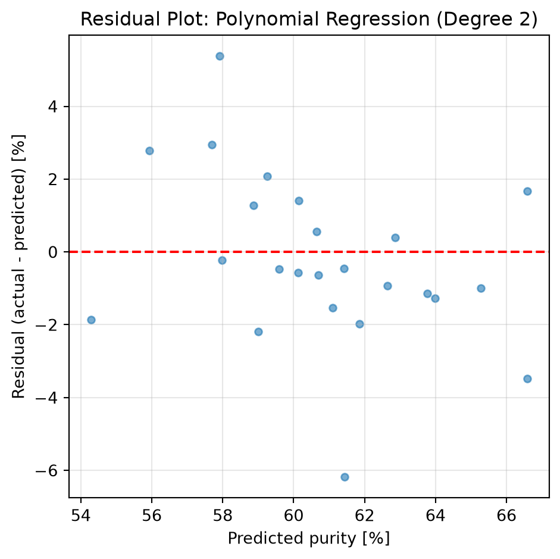

# Regularisation and Overfitting Control

The cross-validated RMSE is minimised at **degree 2**, indicating that this degree provides the best predictive performance on the full training dataset.

For the remainder of this tutorial, however, we will deliberately continue using a **degree-6 polynomial model**. Although it is more complex than necessary for this dataset, it is also much more prone to overfitting. This makes it an ideal example for demonstrating how regularisation methods such as **ridge regression**, **lasso regression**, and **Elastic Net** can control model complexity and improve generalisation.

## Part B: Understanding Overfitting

Before introducing regularisation, it is helpful to understand what overfitting looks like in practice. In the next two tasks, we will examine how model complexity affects the fitted coefficients and explore how a flexible polynomial model behaves when only a limited amount of training data is available.

### Task 8 : Watch the coefficients grow

First, see what actually goes wrong inside an over-flexible model. Write a function `plot_coefficient_growth` that fits polynomials of increasing degree and records the largest coefficient magnitude in each one. Plot it on a logarithmic y-axis.

```
plot_coefficient_growth.py
```

```python
def plot_coefficient_growth(X_train, y_train, max_degree=15):
    """
    Track the largest fitted coefficient magnitude as the polynomial degree increases.

    Parameters
    ----------
    X_train : pd.DataFrame
        The training features.
    y_train : pd.Series
        The training target.
    max_degree : int, optional
        The highest degree to try (default is 15).

    Returns
    -------
    largest : list of float
        The largest absolute coefficient at each degree.
    """
    return largest
```

largest_coefficients = plot_coefficient_growth(X_train, y_train, max_degree=15)

Degree 1: largest |coefficient| = 4.0

Degree 2: largest |coefficient| = 10.1

Degree 3: largest |coefficient| = 13.2

Degree 4: largest |coefficient| = 47.9

Degree 5: largest |coefficient| = 251.5

Degree 6: largest |coefficient| = 742.2

Degree 7: largest |coefficient| = 3541.3

Degree 8: largest |coefficient| = 495.8

Degree 9: largest |coefficient| = 20185.2

Degree 10: largest |coefficient| = 9382.5

Degree 11: largest |coefficient| = 5256.4

Degree 12: largest |coefficient| = 6468.8

Degree 13: largest |coefficient| = 5159.8

Degree 14: largest |coefficient| = 3895.9

Degree 15: largest |coefficient| = 2860.4

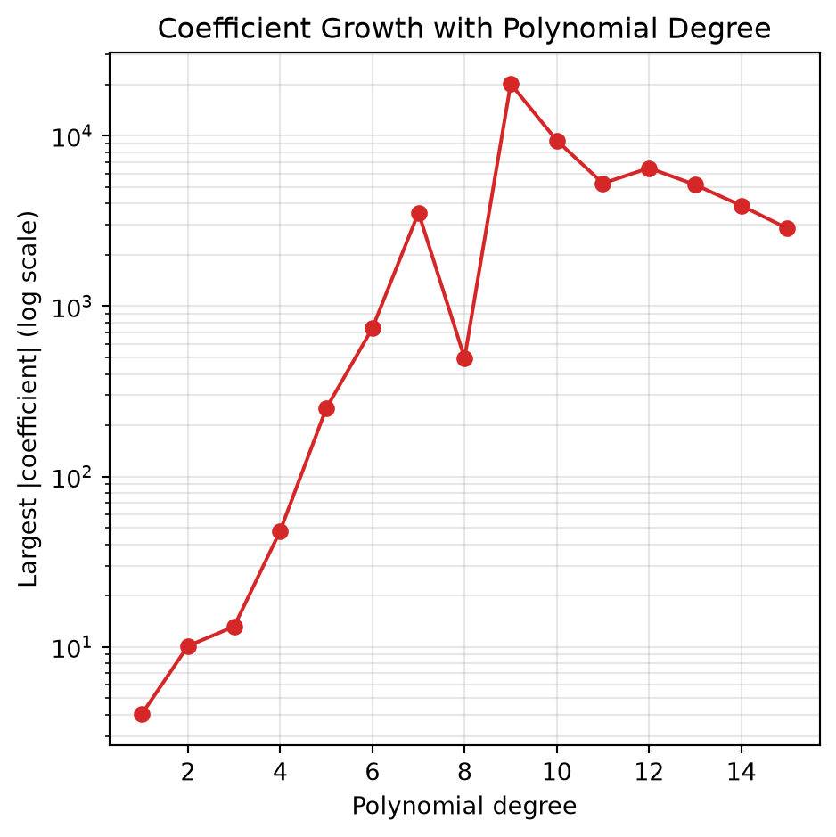

**NoteLarge coefficients and overfitting**

Why does this happen? To create sharp bends, a high-degree polynomial often relies on several large coefficients with opposite signs that almost cancel each other out. The cancellation keeps the fitted curve close to the observed data, while the large coefficients provide the flexibility needed to produce rapid changes in shape.

The problem is that models built from large, nearly cancelling terms are inherently fragile. Small changes in the data can lead to large changes in the fitted coefficients and, consequently, large changes in the predictions.

This observation suggests a natural solution: if excessively large coefficients are a source of instability and overfitting, we can discourage them by adding a penalty for large coefficient values. This idea forms the basis of **regularisation**.

**Callout-answer**Answer**

```
plot_coefficient_growth.py
```

```python
def plot_coefficient_growth(X_train, y_train, max_degree=15):
    """
    Track the largest fitted coefficient magnitude as the polynomial degree increases.

    Parameters
    ----------
    X_train : pd.DataFrame
        The training features.
    y_train : pd.Series
        The training target.
    max_degree : int, optional
        The highest degree to try (default is 15).

    Returns
    -------
    largest : list of float
        The largest absolute coefficient at each degree.
    """
    degrees = list(range(1, max_degree + 1))
    largest = []

    for degree in degrees:
        model = build_polynomial_model(degree).fit(X_train, y_train)

        # The coefficients sit on the last step of the pipeline
        coefficients = model[-1].coef_
        largest.append(np.abs(coefficients).max())
        print(f"Degree {degree:2d}:  largest |coefficient| = {largest[-1]:12.1f}")

    plt.figure(figsize=(5, 5))
    plt.semilogy(degrees, largest, "o-", color="C3")
    plt.xlabel("Polynomial degree")
    plt.ylabel("Largest |coefficient| (log scale)")
    plt.title("Coefficient Growth with Polynomial Degree")
    plt.grid(True, alpha=0.3, which="both")
    plt.tight_layout()
    plt.show()
    return largest

largest_coefficients = plot_coefficient_growth(X_train, y_train, max_degree=15)
```

Output

```
Degree  1:  largest |coefficient| =          4.0
Degree  2:  largest |coefficient| =         10.1
Degree  3:  largest |coefficient| =         13.2
Degree  4:  largest |coefficient| =         47.9
Degree  5:  largest |coefficient| =        251.5
Degree  6:  largest |coefficient| =        742.2
Degree  7:  largest |coefficient| =       3541.3
Degree  8:  largest |coefficient| =        495.8
Degree  9:  largest |coefficient| =      20185.2
Degree 10:  largest |coefficient| =       9382.5
Degree 11:  largest |coefficient| =       5256.4
Degree 12:  largest |coefficient| =       6468.8
Degree 13:  largest |coefficient| =       5159.8
Degree 14:  largest |coefficient| =       3895.9
Degree 15:  largest |coefficient| =       2860.4
```

Output

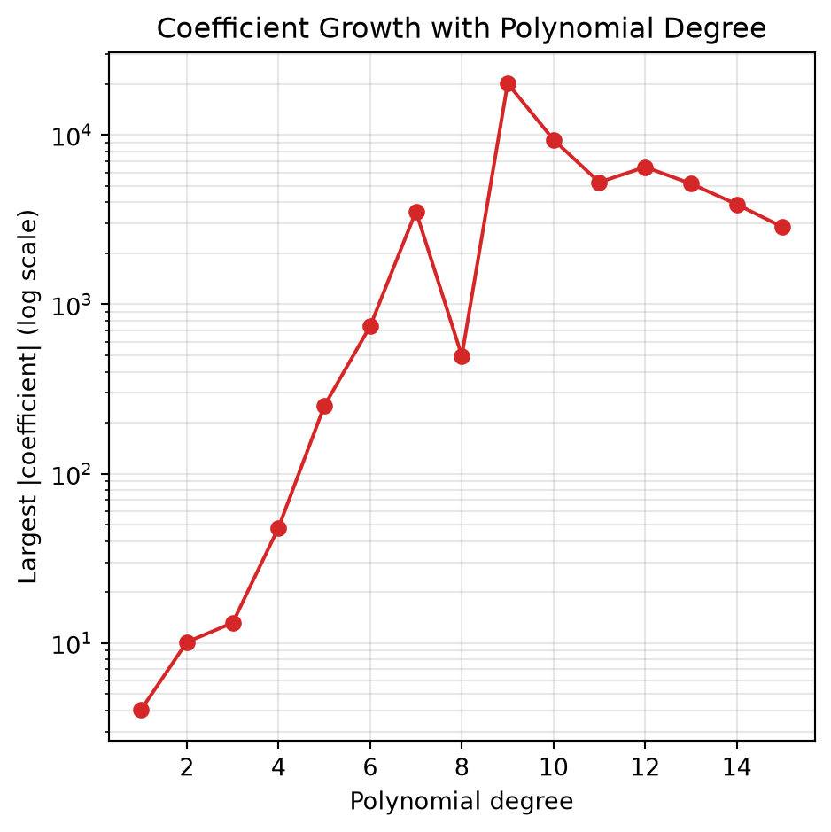

### Task: 9 Exposing overfitting with less data

The overfitting observed in Part A was relatively mild because the training set contained many observations. In practice, experimental data can be expensive and time-consuming to collect, meaning that much smaller datasets are often available.

To see how limited data affects model behaviour, create a reduced training set containing only the first 20 observations. Fit a degree-6 polynomial model to this reduced dataset, evaluate its performance on the same held-out test set, and plot the fitted curve.

Compare the result with the degree-6 model trained on the full dataset. What changes do you observe in the fitted curve, the test-set performance, and the coefficient magnitudes?

X_small = X_train.iloc[:20]

y_small = y_train.iloc[:20]

print(f"Reduced training set: {X_small.shape[0]} runs")

Reduced training set: 20 runs

small_poly = build_polynomial_model(degree=6).fit(X_small, y_small)

small_metrics = evaluate_regression(small_poly, X_test, y_test)

MAE: 2.173

MSE: 7.591

RMSE: 2.755

R2: 0.213

print(f"Largest |coefficient|: {np.abs(small_poly[-1].coef_).max():.1f}")

Largest |coefficient|: 2643.1

print(f"Full training set: {X_train.shape[0]} runs")

Full training set: 96 runs

poly_model = build_polynomial_model(degree=6).fit(X_train, y_train)

poly_metrics = evaluate_regression(poly_model, X_test, y_test)

MAE: 1.633

MSE: 4.553

RMSE: 2.134

R2: 0.528

print(f"Largest |coefficient|: {np.abs(poly_model[-1].coef_).max():.1f}")

Largest |coefficient|: 742.2

plot_fitted_curves({"Degree 6, no penalty": small_poly}, X_small, y_small, "Degree 6 fitted to only 20 runs")

plot_fitted_curves({"Degree 6, no penalty": poly_model}, X_train, y_train, "Degree 6 fitted to all runs")

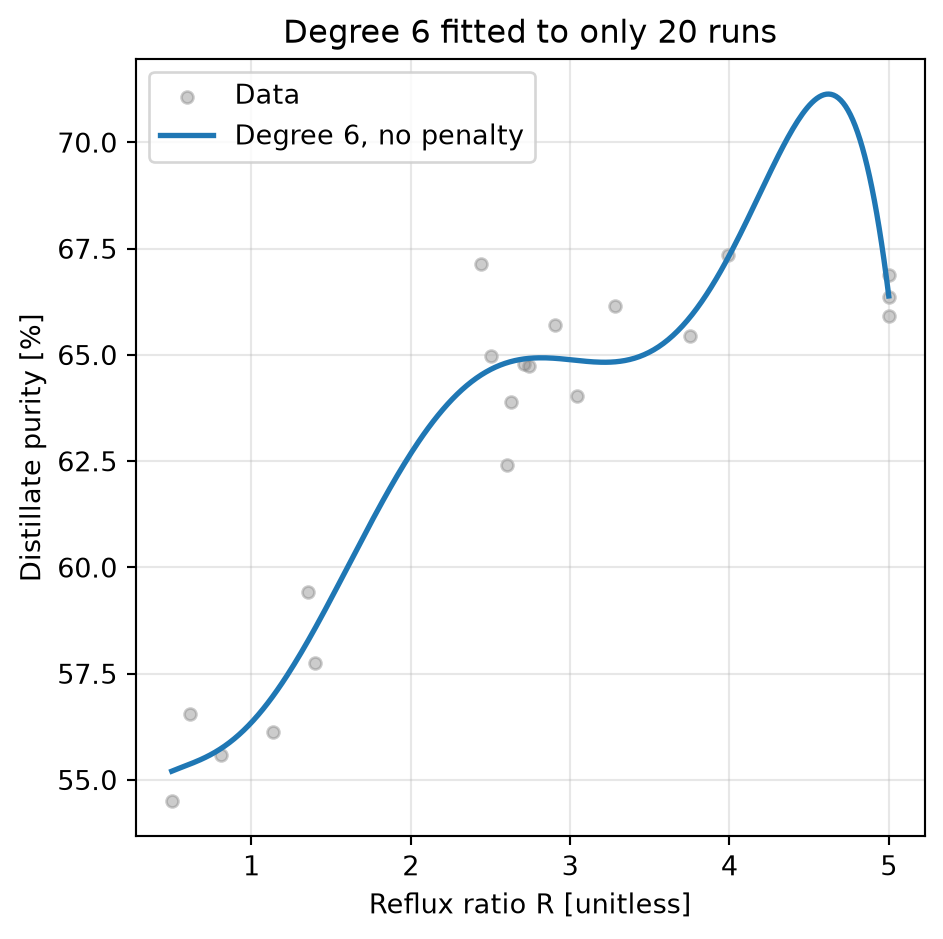

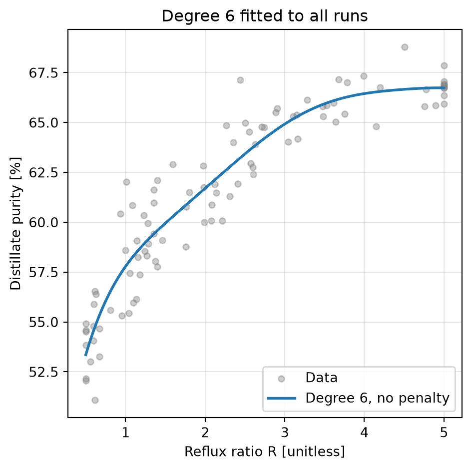

**Callout-answer**Answer**

```python
# Both functions were written earlier and work unchanged on the smaller training set.
X_small = X_train.iloc[:20]
y_small = y_train.iloc[:20]

print(f"Reduced training set: {X_small.shape[0]} runs")
small_poly = build_polynomial_model(degree=6).fit(X_small, y_small)
small_metrics = evaluate_regression(small_poly, X_test, y_test)
print(f"Largest |coefficient|: {np.abs(small_poly[-1].coef_).max():.1f}")

print(f"Full training set: {X_train.shape[0]} runs")
poly_model = build_polynomial_model(degree=6).fit(X_train, y_train)
poly_metrics = evaluate_regression(poly_model, X_test, y_test)
print(f"Largest |coefficient|: {np.abs(poly_model[-1].coef_).max():.1f}")

plot_fitted_curves({"Degree 6, no penalty": small_poly},
                   X_small, y_small, "Degree 6 fitted to only 20 runs")
plot_fitted_curves({"Degree 6, no penalty": poly_model},
                    X_train, y_train, "Degree 6 fitted to all runs")
```

Output

```
Reduced training set: 20 runs
MAE:  2.173
MSE:  7.591
RMSE: 2.755
R2:   0.213
Largest |coefficient|: 2643.1
Full training set: 96 runs
MAE:  1.633
MSE:  4.553
RMSE: 2.134
R2:   0.528
Largest |coefficient|: 742.2
```

Output

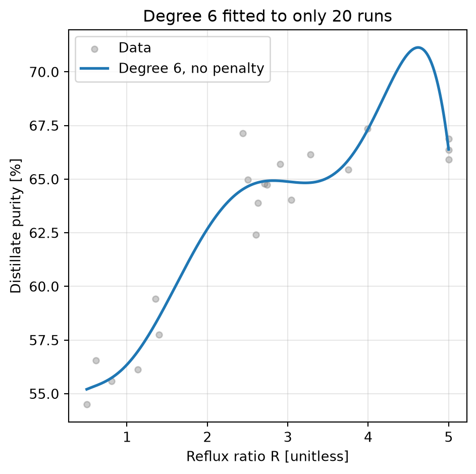

Output

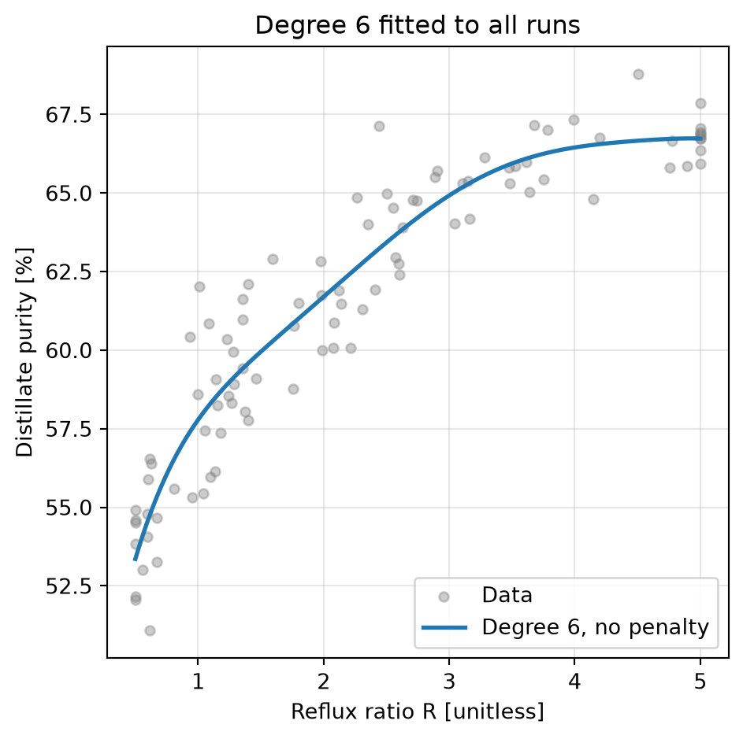

The degree-6 model fitted to only 20 observations shows signs of overfitting. Compared with the model trained on all 96 observations, the fitted curve becomes less stable and exhibits more pronounced curvature near the upper end of the reflux ratio range.

This change is reflected in the test-set performance. The $R^2$ decreases from **0.53** to **0.21**, while the RMSE increases from **2.13** to **2.76** when the training set is reduced from 96 to 20 observations. This indicates that the model’s ability to generalise to unseen data has deteriorated.

The largest coefficient also increases substantially, from approximately **742** to **2643**. This suggests that the model is relying on larger coefficient values to fit the limited data, making it more sensitive to noise and increasing the risk of overfitting.

## Part C: Ridge Regularisation

The previous tasks showed that highly flexible models can become unstable when data are limited. The degree-6 polynomial fitted to only 20 observations produced very large coefficients and performed poorly on unseen data, despite fitting the training data well.

Selecting the polynomial degree can improve model performance, but it is a relatively coarse way to control model complexity because it only allows terms to be added or removed. **Regularisation** provides a more flexible approach.

Instead of reducing the complexity of the model by lowering its degree, regularisation keeps the flexible model in place and adds a penalty for large coefficient values. This penalty discourages the model from using unnecessary complexity unless it leads to a meaningful improvement in performance. As a result, regularisation can help reduce overfitting while retaining the ability to capture nonlinear relationships in the data.

### Task: 10 Add a Ridge penalty

**NoteWhat Ridge Regression Does**

Ordinary least squares chooses the coefficients that minimise only the sum of squared errors. Ridge regression adds an additional penalty on the size of the coefficients:

$$\text{minimise} \quad
\sum_{i=1}^{n}\left(y_i-\hat{y}_i\right)^2
+
\alpha \sum_{j=1}^{d} w_j^2$$

The second term is known as an **L2 penalty**. It discourages large coefficient values, forcing the model to balance two competing objectives:

1. fitting the training data accurately, and
2. keeping the coefficients small.

The hyperparameter $\alpha$ controls the strength of this penalty. When $\alpha = 0$, ridge regression is identical to ordinary least squares. As $\alpha$ increases, the coefficients are progressively shrunk towards zero, reducing model flexibility and helping to prevent overfitting.

Notice that the intercept ($w_0$) is not penalised. Penalising the intercept would simply shift all predictions towards zero, which is usually undesirable.

Because the penalty acts directly on the coefficients, it is important that all features are on comparable scales. This is why the `StandardScaler` step remains an essential part of the pipeline. Without scaling, features with larger numerical values would receive disproportionately large penalties, leading to an unfair and ineffective form of regularisation.

The degree-6 polynomial model fitted to only 20 observations exhibited severe overfitting, with large coefficient values and poor performance on the test set. Rather than reducing the polynomial degree, another approach is to keep the flexible model and constrain its complexity using **regularisation**.

Write a function `build_ridge_model` that returns the same pipeline as `build_polynomial_model`, but replaces `LinearRegression` with `Ridge`. Fit a degree-6 ridge model with `alpha=1.0` to the 20-run training set, evaluate its performance on the same test set, and plot the fitted curve.

Compare the fitted curve, test-set performance, and coefficient magnitudes with those of the unregularised degree-6 model.

```
build_ridge_model.py
```

```python
def build_ridge_model(degree, alpha):
    """
    Build an unfitted polynomial ridge regression pipeline.

    Parameters
    ----------
    degree : int
        The highest power of the feature to include.
    alpha : float
        The regularisation strength. Larger values shrink the coefficients harder.

    Returns
    -------
    model : Pipeline
        An unfitted pipeline of PolynomialFeatures, StandardScaler and Ridge.
    """
```

ridge_model = build_ridge_model(degree=6, alpha=1.0).fit(X_small, y_small)

ridge_metrics = evaluate_regression(ridge_model, X_test, y_test)

MAE: 1.695

MSE: 5.188

RMSE: 2.278

R2: 0.462

print(f"Largest |coefficient|: {np.abs(ridge_model[-1].coef_).max():.1f}")

Largest |coefficient|: 4.4

How has the model performance changed? How has the largest coefficient changed? What does that tell you about the effect of the penalty?

**Callout-answer**Answer**

```
build_ridge_model.py
```

```python
def build_ridge_model(degree, alpha):
    """
    Build an unfitted polynomial ridge regression pipeline.

    Parameters
    ----------
    degree : int
        The highest power of the feature to include.
    alpha : float
        The regularisation strength. Larger values shrink the coefficients harder.

    Returns
    -------
    model : Pipeline
        An unfitted pipeline of PolynomialFeatures, StandardScaler and Ridge.
    """
    model = make_pipeline(
        PolynomialFeatures(degree=degree, include_bias=False),
        StandardScaler(),
        Ridge(alpha=alpha),
    )
    return model

ridge_model = build_ridge_model(degree=6, alpha=1.0).fit(X_small, y_small)
ridge_metrics = evaluate_regression(ridge_model, X_test, y_test)
print(f"Largest |coefficient|: {np.abs(ridge_model[-1].coef_).max():.1f}")
```

Output

```
MAE:  1.695
MSE:  5.188
RMSE: 2.278
R2:   0.462
Largest |coefficient|: 4.4
```

The ridge penalty improves test-set performance, reducing the RMSE from **2.76** to **2.28** and increasing $R^2$ from **0.21** to **0.46**.

The largest coefficient also drops dramatically, from approximately **2643** to **4.4**. This shows that the ridge penalty shrinks large coefficients, producing a simpler and more stable model that generalises better to unseen data.

### Task 11 : See what alpha does to the curve

Reuse `plot_fitted_curves` to draw the degree-6 model at several regularisation strengths spanning five orders of magnitude, so you can see the shape the dial actually controls.

alpha_models = {"No penalty": small_poly}

for alpha in [0.01, 1.0, 1000.0]:

alpha_models[f"alpha = {alpha}"] = build_ridge_model(6, alpha).fit(X_small, y_small)

plot_fitted_curves(alpha_models, X_small, y_small,

"Effect of the Ridge Penalty (Degree 6)")

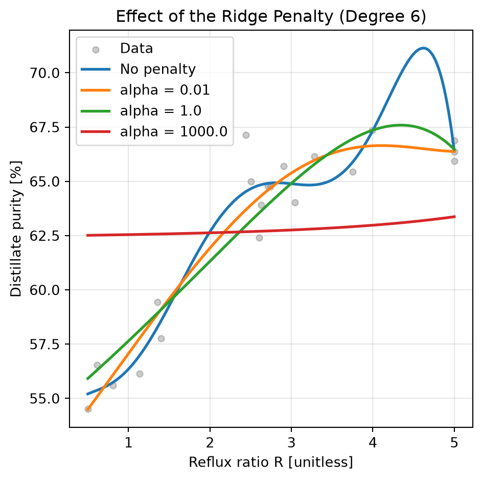

Reading the curves from the wiggliest to the flattest gives you the whole bias-variance trade-off in one picture. With no penalty the model chases every point. A light penalty keeps the saturating shape but removes the wandering. A heavy penalty crushes the model back to something close to a flat line, which is underfitting again, reached from the opposite direction. Notice that degree is no longer what controls the complexity: `alpha` is.

**Callout-answer**Answer**

```python
# plot_fitted_curves takes any dictionary of fitted models, so it works unchanged here.
alpha_models = {"No penalty": small_poly}
for alpha in [0.01, 1.0, 1000.0]:
    alpha_models[f"alpha = {alpha}"] = build_ridge_model(6, alpha).fit(X_small, y_small)

plot_fitted_curves(alpha_models, X_small, y_small,
                   "Effect of the Ridge Penalty (Degree 6)")
```

Output

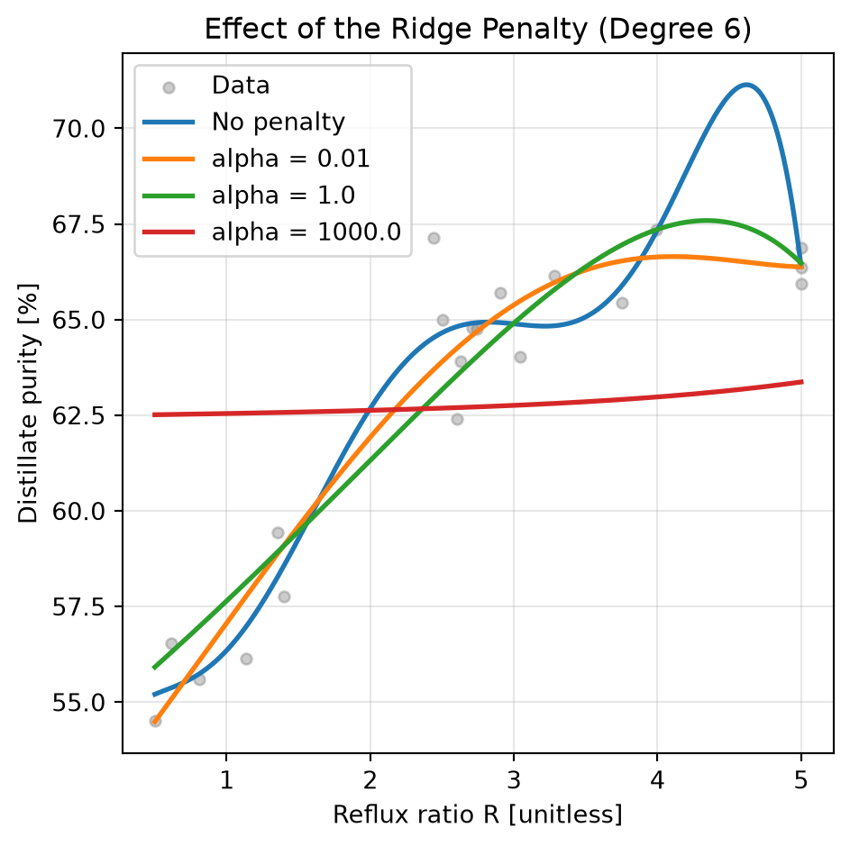

### Task 12 : Choose alpha by cross-validation

Finally, select `alpha` the same way you selected the degree. Write a function `plot_alpha_sweep_ridge` that loops over a range of regularisation strengths, records the training RMSE and the 5-fold cross-validated RMSE for each, and plots both against `alpha` on a logarithmic x-axis.

**TipSweeping a hyperparameter across orders of magnitude**

A sensible `alpha` might be 0.001 or it might be 1000, and stepping evenly between them would waste almost every trial at the large end. `np.logspace(-3, 3, 7)` returns 7 values spaced evenly in the **exponent** instead: 10⁻³, 10⁻², …, 10³. Match it with `plt.xscale("log")` so the plot is evenly spaced too. See the [np.logspace documentation](https://numpy.org/doc/stable/reference/generated/numpy.logspace.html).

```
plot_alpha_sweep_ridge.py
```

```python
def plot_alpha_sweep_ridge(X_train, y_train, degree, alphas):
    """
    Plot training and cross-validated RMSE as a function
    of the ridge regularisation strength, alpha.

    Parameters
    ----------
    X_train : pd.DataFrame
        Training features.
    y_train : pd.Series
        Training targets.
    degree : int
        Polynomial degree used in the ridge model.
    alphas : array-like
        Sequence of alpha values to evaluate.

    Returns
    -------
    cv_rmse : list
        Mean cross-validated RMSE for each alpha value.
    """
    return cv_rmse
```

alphas = np.logspace(-3, 3, 7)

cv_rmse = plot_alpha_sweep_ridge(X_small, y_small, degree=6, alphas=alphas)

alpha = 0.001: train RMSE = 1.172 CV RMSE = 1.442

alpha = 0.010: train RMSE = 1.194 CV RMSE = 1.415

alpha = 0.100: train RMSE = 1.234 CV RMSE = 1.406

alpha = 1.000: train RMSE = 1.389 CV RMSE = 1.507

alpha = 10.000: train RMSE = 2.340 CV RMSE = 2.657

alpha = 100.000: train RMSE = 3.403 CV RMSE = 3.589

alpha = 1000.000: train RMSE = 4.076 CV RMSE = 4.181

best_alpha = alphas[np.argmin(cv_rmse)]

print(f"Best alpha by cross-validation: {best_alpha}")

Best alpha by cross-validation: 0.1

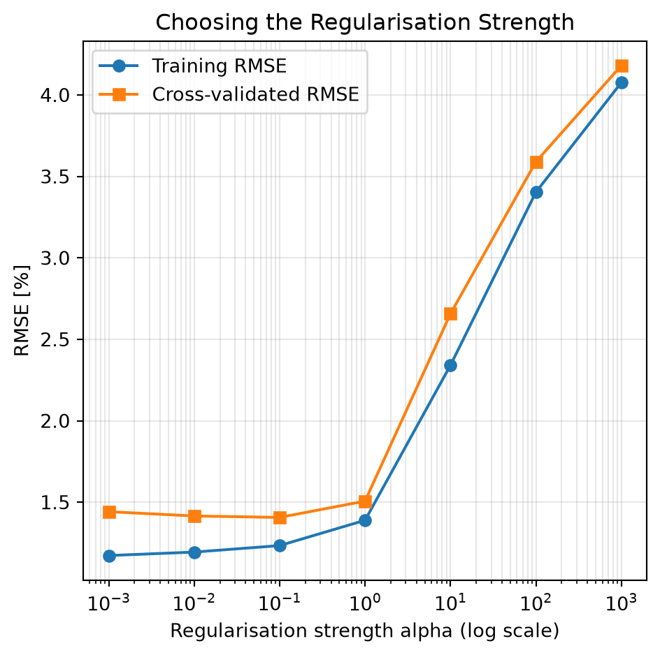

**Callout-answer**Answer**

```
plot_alpha_sweep_ridge.py
```

```python
def plot_alpha_sweep_ridge(X_train, y_train, degree, alphas):
    """
    Plot training and cross-validated RMSE as a function
    of the ridge regularisation strength, alpha.

    Parameters
    ----------
    X_train : pd.DataFrame
        Training features.
    y_train : pd.Series
        Training targets.
    degree : int
        Polynomial degree used in the ridge model.
    alphas : array-like
        Sequence of alpha values to evaluate.

    Returns
    -------
    cv_rmse : list
        Mean cross-validated RMSE for each alpha value.
    """
    train_rmse, cv_rmse = [], []

    for alpha in alphas:
        # Build a ridge model with the current alpha
        model = build_ridge_model(degree, alpha)

        # Estimate performance using 5-fold cross-validation
        scores = cross_val_score(model, X_train, y_train, cv=5,
                                 scoring="neg_root_mean_squared_error")
        cv_rmse.append(-scores.mean())

        # Fit the model to the full training set and calculate the training RMSE
        model.fit(X_train, y_train)
        train_rmse.append(np.sqrt(mean_squared_error(y_train, model.predict(X_train))))

        print(f"  alpha = {alpha:8.3f}:  train RMSE = {train_rmse[-1]:.3f}   CV RMSE = {cv_rmse[-1]:.3f}")

    # Plot training and cross-validation error
    plt.figure(figsize=(5, 5))
    plt.plot(alphas, train_rmse, "o-", label="Training RMSE")
    plt.plot(alphas, cv_rmse, "s-", label="Cross-validated RMSE")
    plt.xscale("log")
    plt.xlabel("Regularisation strength alpha (log scale)")
    plt.ylabel("RMSE [%]")
    plt.title("Choosing the Regularisation Strength")
    plt.legend()
    plt.grid(True, alpha=0.3, which="both")
    plt.tight_layout()
    plt.show()
    return cv_rmse

alphas = np.logspace(-3, 3, 7)
cv_rmse = plot_alpha_sweep_ridge(X_small, y_small, degree=6, alphas=alphas)
best_alpha = alphas[np.argmin(cv_rmse)]
print(f"Best alpha by cross-validation: {best_alpha}")
```

Output

```
  alpha =    0.001:  train RMSE = 1.172   CV RMSE = 1.442
  alpha =    0.010:  train RMSE = 1.194   CV RMSE = 1.415
  alpha =    0.100:  train RMSE = 1.234   CV RMSE = 1.406
  alpha =    1.000:  train RMSE = 1.389   CV RMSE = 1.507
  alpha =   10.000:  train RMSE = 2.340   CV RMSE = 2.657
  alpha =  100.000:  train RMSE = 3.403   CV RMSE = 3.589
  alpha = 1000.000:  train RMSE = 4.076   CV RMSE = 4.181
```

Output

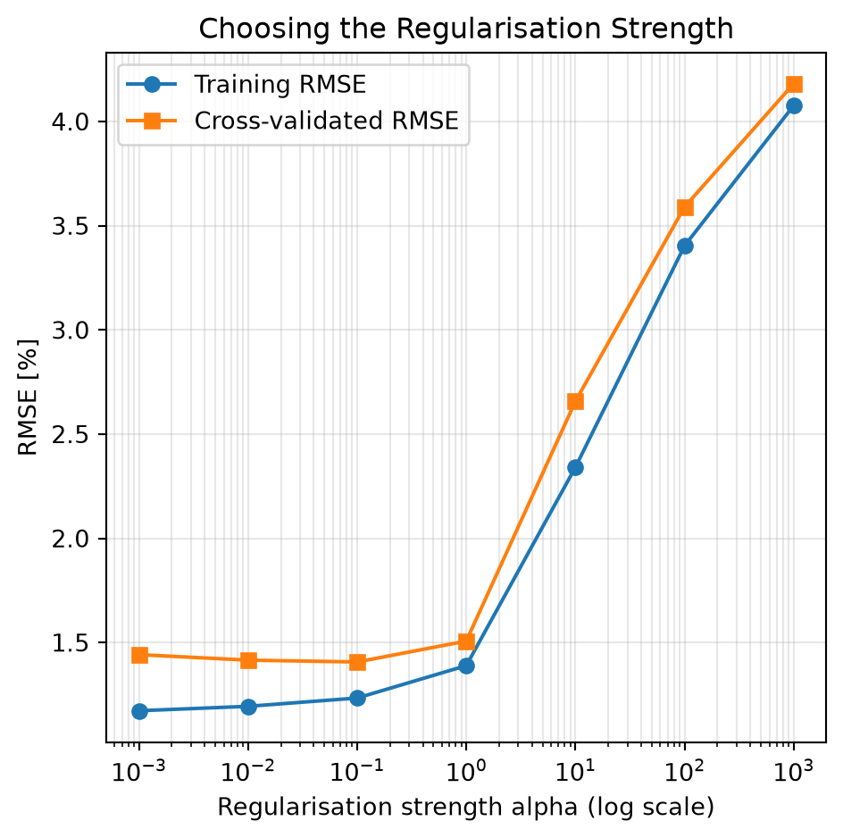

Output

```
Best alpha by cross-validation: 0.1
```

### Task 13 : Compare the regularised and unregularised models

You have now identified a suitable value of the ridge regularisation strength, $\alpha$. Refit the degree-6 ridge model using this value and evaluate its performance on the test set.

final_model = build_ridge_model(degree=6, alpha=best_alpha).fit(X_small, y_small)

final_metrics = evaluate_regression(final_model, X_test, y_test)

MAE: 1.795

MSE: 5.543

RMSE: 2.354

R2: 0.425

Next, write a function, `plot_coefficients`, that accepts a dictionary of `{label: fitted_model}` and plots the coefficients of multiple fitted models on the same figure. Use this function to compare the coefficients of the ridge-regularised model with those of the unregularised polynomial model.

**Tipsymlog**

Coefficient values can differ by several orders of magnitude, especially when comparing regularised and unregularised models. Consider using a symmetric logarithmic scale (`symlog`) for the coefficient axis. Unlike a standard logarithmic scale, `symlog` can display both positive and negative values while compressing very large magnitudes, making coefficient comparisons much easier to interpret.

```
plot_coefficients.py
```

```python
def plot_coefficients(models, title="Coefficient Comparison"):
    """
    Compare coefficients from multiple fitted pipeline models.

    Parameters
    ----------
    models : dict
        Dictionary of {label: fitted_model}.
    title : str, optional
        Plot title.
    """
```

Notice that the coefficients correspond to the **standardised polynomial features** generated by the pipeline. Their magnitudes can therefore be compared directly, but they do not represent the coefficients of the polynomial expressed in the original reflux-ratio units.

print("No penalty:")

No penalty:

for i, coef in enumerate(small_poly[-1].coef_):

print(f"R^{i+1}: {coef:.3f}")

R^1: 20.587

R^2: -235.605

R^3: 1205.839

R^4: -2643.062

R^5: 2580.630

R^6: -925.354

print("Ridge:")

Ridge:

for i, coef in enumerate(final_model[-1].coef_):

print(f"R^{i+1}: {coef:.3f}")

R^1: 6.400

R^2: 0.793

R^3: -1.817

R^4: -1.909

R^5: -0.830

R^6: 0.565

plot_coefficients({"No penalty": small_poly,"Ridge": final_model},

title="Effect of Ridge Regularisation")

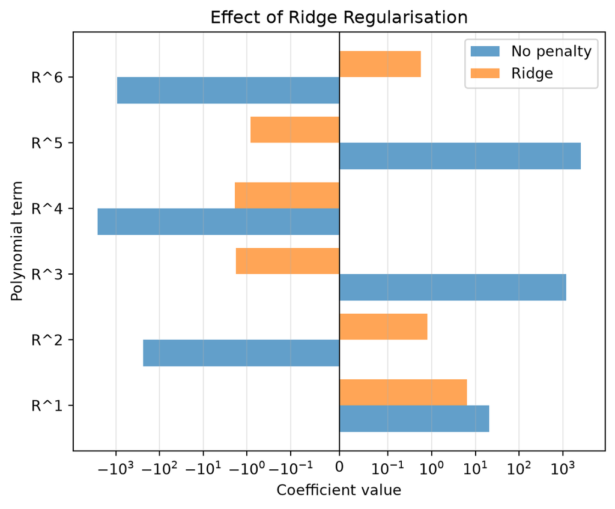

The ridge penalty substantially reduces the magnitude of the polynomial coefficients. This coefficient shrinkage reduces the model’s flexibility and sensitivity to noise, helping to prevent overfitting. As a result, the ridge-regularised model is more stable and achieves better predictive performance on unseen data.

**NoteRidge is not the only penalty**

The squared-coefficient penalty that ridge uses is the most common, but it is not the only way to charge a model for complexity. In Part D we meet two more penalties that plug into the very same pipeline and behave rather differently, one of which does something ridge cannot: it removes terms from the model entirely.

**Callout-answer**Answer**

```
plot_coefficients.py
```

```python
def plot_coefficients(models, title="Coefficient Comparison"):
    """
    Compare coefficients from multiple fitted pipeline models.

    Parameters
    ----------
    models : dict
        Dictionary of {label: fitted_model}.
    title : str, optional
        Plot title.
    """
    n_models = len(models)

    # Get coefficient names from the first model
    first_model = next(iter(models.values()))
    n_coef = len(first_model[-1].coef_)

    feature_names = [f"R^{i}" for i in range(1, n_coef + 1)]
    y = np.arange(n_coef)

    bar_height = 0.8 / n_models

    plt.figure(figsize=(6, 5))

    for i, (label, model) in enumerate(models.items()):
        offset = (i - (n_models - 1) / 2) * bar_height

        plt.barh(
            y + offset,
            model[-1].coef_,
            height=bar_height,
            label=label,
            alpha=0.7,
        )

    plt.xscale("symlog", linthresh=0.1)
    plt.yticks(y, feature_names)
    plt.axvline(0, color="k", linewidth=0.8)

    plt.xlabel("Coefficient value")
    plt.ylabel("Polynomial term")
    plt.title(title)
    plt.legend()
    plt.grid(True, alpha=0.3, axis="x")
    plt.tight_layout()
    plt.show()

print("No penalty:")
for i, coef in enumerate(small_poly[-1].coef_):
    print(f"R^{i+1}: {coef:.3f}")

print("Ridge:")
for i, coef in enumerate(final_model[-1].coef_):
    print(f"R^{i+1}: {coef:.3f}")

plot_coefficients({"No penalty": small_poly,"Ridge": final_model},
    title="Effect of Ridge Regularisation")
```

Output

```
No penalty:
R^1: 20.587
R^2: -235.605
R^3: 1205.839
R^4: -2643.062
R^5: 2580.630
R^6: -925.354
Ridge:
R^1: 6.400
R^2: 0.793
R^3: -1.817
R^4: -1.909
R^5: -0.830
R^6: 0.565
```

Output

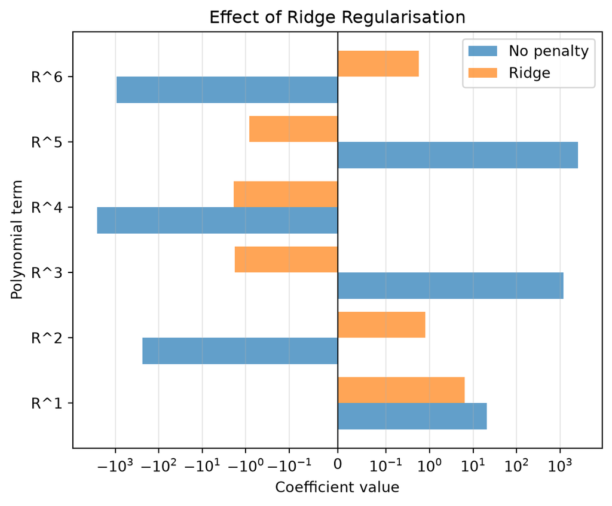

## Part D: Sparse Regularisation with Lasso and Elastic Net

Ridge shrank the coefficients but never removed any: the final model in Part C still carried all polynomial terms, some of them contributing almost nothing. That is a property of the *squared* penalty. Two other penalties, built from the same pipeline, behave differently, and the difference turns out to be useful.

### Task 14 : Add a Lasso penalty and see what alpha does to the curve

**NoteWhat Lasso Regression Does**

Ordinary least squares chooses the coefficients that minimise only the sum of squared errors. Lasso regression adds an additional penalty on the absolute size of the coefficients:

$$\text{minimise} \quad
\sum_{i=1}^{n}\left(y_i-\hat{y}_i\right)^2
+
\alpha \sum_{j=1}^{d} |w_j|$$

The second term is known as an **L1 penalty**. Like ridge regression, it discourages large coefficient values, forcing the model to balance two competing objectives:

1. fitting the training data accurately, and
2. keeping the coefficients small.

The hyperparameter $\alpha$ controls the strength of the penalty. When $\alpha = 0$, lasso regression is identical to ordinary least squares. As $\alpha$ increases, the coefficients are progressively shrunk towards zero.

A key difference from ridge regression is that lasso can shrink some coefficients **exactly to zero**. This effectively removes the corresponding features from the model, making lasso a form of **automatic feature selection**.

As with ridge regression, the intercept ($w_0$) is not penalised. Penalising the intercept would simply shift all predictions towards zero, which is usually undesirable.

Write a function `build_lasso_model` that returns the familiar pipeline with `Lasso` as the final step in place of `Ridge` and reuse the `plot_fitted_curves` function developed earlier to examine how the fitted curve changes as the lasso regularisation strength ($\alpha$) increases

**TipLasso needs an iteration budget**

`LinearRegression` and `Ridge` are solved in one closed-form step, but `Lasso` and `ElasticNet` are fitted by an iterative routine called coordinate descent. On awkwardly scaled or highly correlated features (and powers of the same variable are very correlated) that routine can hit its default iteration cap before it settles, and scikit-learn prints a `ConvergenceWarning`. Giving it more room with `max_iter=500000` clears this up. If you ever see that warning, raising `max_iter` is the first thing to try. See the [Lasso documentation](https://scikit-learn.org/stable/modules/generated/sklearn.linear_model.Lasso.html).

```
build_lasso_model.py
```

```python
def build_lasso_model(degree, alpha):
    """
    Build an unfitted polynomial Lasso (L1) regression pipeline.

    Parameters
    ----------
    degree : int
        The highest power of the feature to include.
    alpha : float
        The regularisation strength.

    Returns
    -------
    model : Pipeline
        An unfitted pipeline of PolynomialFeatures, StandardScaler and Lasso.
    """
```

After defining `build_lasso_model`, use it to fit lasso models with different values of $\alpha$, and then reuse the `plot_fitted_curves` function developed earlier to compare the resulting fits. When you run `plot_fitted_curves`, it should yield the following output:

alpha_models = {"No penalty": small_poly}

for alpha in [0.01, 1.0, 1000.0]:

alpha_models[f"alpha = {alpha}"] = build_lasso_model(6, alpha).fit(X_small, y_small)

plot_fitted_curves(alpha_models, X_small, y_small,

"Effect of the Lasso Penalty (Degree 6)")

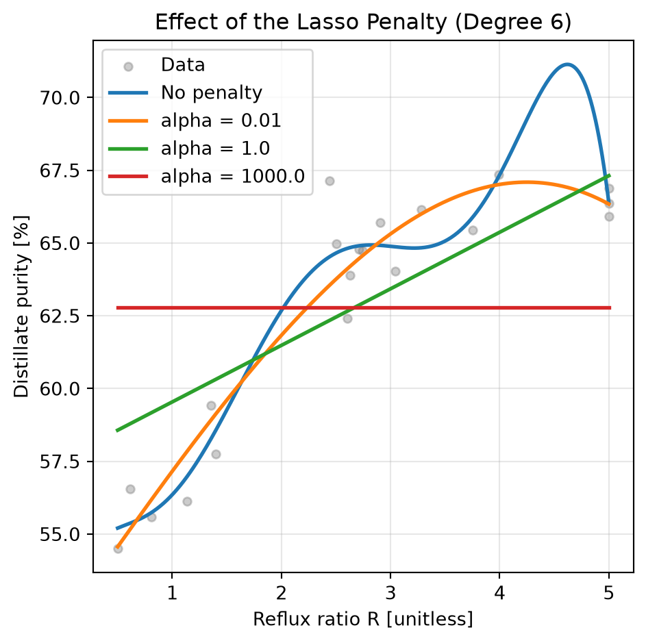

Notice that larger values of $\alpha$ produce progressively simpler models by shrinking more coefficients towards zero. As a result, the fitted curve becomes smoother and less flexible, eventually approaching a nearly straight line when the penalty is very strong.

### Task 15 : Choose alpha by cross-validation

Next, write a function `plot_alpha_sweep_lasso` that evaluates a degree-6 lasso model over a range of $\alpha$ values. For each value, record the training RMSE and the 5-fold cross-validated RMSE, then plot both against $\alpha$ on a logarithmic scale.

Use the cross-validation results to select an appropriate value of $\alpha$.

**TipHint**

Reuse the workflow from `plot_alpha_sweep_ridge`, and replace `build_ridge_model` with `build_lasso_model` and remember to convert the negative RMSE values returned by `cross_val_score()` back to positive RMSE values.

alphas = np.logspace(-3, 3, 7)

cv_rmse = plot_alpha_sweep_lasso(X_small, y_small, degree=6, alphas=alphas)

alpha = 0.001: train RMSE = 1.178 CV RMSE = 1.480

alpha = 0.010: train RMSE = 1.218 CV RMSE = 1.407

alpha = 0.100: train RMSE = 1.321 CV RMSE = 1.443

alpha = 1.000: train RMSE = 2.359 CV RMSE = 2.561

alpha = 10.000: train RMSE = 4.253 CV RMSE = 4.328

alpha = 100.000: train RMSE = 4.253 CV RMSE = 4.328

alpha = 1000.000: train RMSE = 4.253 CV RMSE = 4.328

best_alpha = alphas[np.argmin(cv_rmse)]

print(f"Best alpha by cross-validation: {best_alpha}")

Best alpha by cross-validation: 0.01

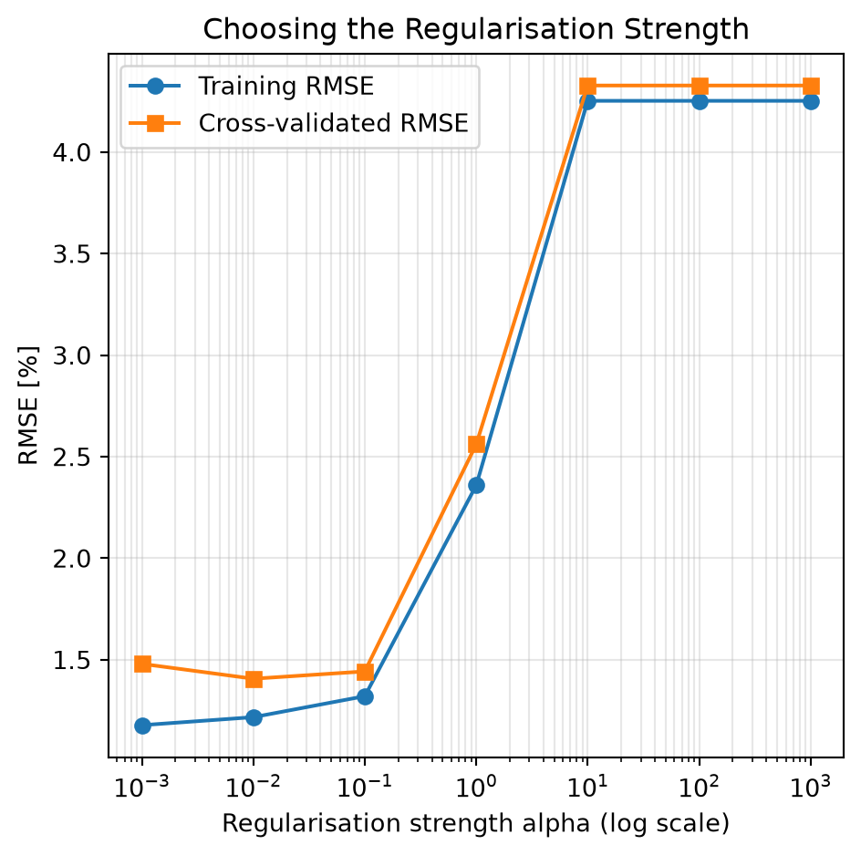

**Callout-answer**Answer**

```
plot_alpha_sweep_lasso.py
```

```python
def plot_alpha_sweep_lasso(X_train, y_train, degree, alphas):
    """
    Plot training and cross-validated RMSE as a function
    of the lasso regularisation strength, alpha.

    Parameters
    ----------
    X_train : pd.DataFrame
        Training features.
    y_train : pd.Series
        Training targets.
    degree : int
        Polynomial degree used in the lasso model.
    alphas : array-like
        Sequence of alpha values to evaluate.

    Returns
    -------
    cv_rmse : list
        Mean cross-validated RMSE for each alpha value.
    """
    train_rmse, cv_rmse = [], []

    for alpha in alphas:
        # Build a lasso model with the current alpha
        model = build_lasso_model(degree, alpha)

        # Estimate performance using 5-fold cross-validation
        scores = cross_val_score(model, X_train, y_train, cv=5,
                                 scoring="neg_root_mean_squared_error")
        cv_rmse.append(-scores.mean())

        # Fit the model to the full training set and calculate the training RMSE
        model.fit(X_train, y_train)
        train_rmse.append(np.sqrt(mean_squared_error(y_train, model.predict(X_train))))

        print(f"  alpha = {alpha:8.3f}:  train RMSE = {train_rmse[-1]:.3f}   CV RMSE = {cv_rmse[-1]:.3f}")

    # Plot training and cross-validation error
    plt.figure(figsize=(5, 5))
    plt.plot(alphas, train_rmse, "o-", label="Training RMSE")
    plt.plot(alphas, cv_rmse, "s-", label="Cross-validated RMSE")
    plt.xscale("log")
    plt.xlabel("Regularisation strength alpha (log scale)")
    plt.ylabel("RMSE [%]")
    plt.title("Choosing the Regularisation Strength")
    plt.legend()
    plt.grid(True, alpha=0.3, which="both")
    plt.tight_layout()
    plt.show()
    return cv_rmse

alphas = np.logspace(-3, 3, 7)
cv_rmse = plot_alpha_sweep_lasso(X_small, y_small, degree=6, alphas=alphas)
best_alpha = alphas[np.argmin(cv_rmse)]
print(f"Best alpha by cross-validation: {best_alpha}")
```

Output

```
  alpha =    0.001:  train RMSE = 1.178   CV RMSE = 1.480
  alpha =    0.010:  train RMSE = 1.218   CV RMSE = 1.407
  alpha =    0.100:  train RMSE = 1.321   CV RMSE = 1.443
  alpha =    1.000:  train RMSE = 2.359   CV RMSE = 2.561
  alpha =   10.000:  train RMSE = 4.253   CV RMSE = 4.328
  alpha =  100.000:  train RMSE = 4.253   CV RMSE = 4.328
  alpha = 1000.000:  train RMSE = 4.253   CV RMSE = 4.328
```

Output

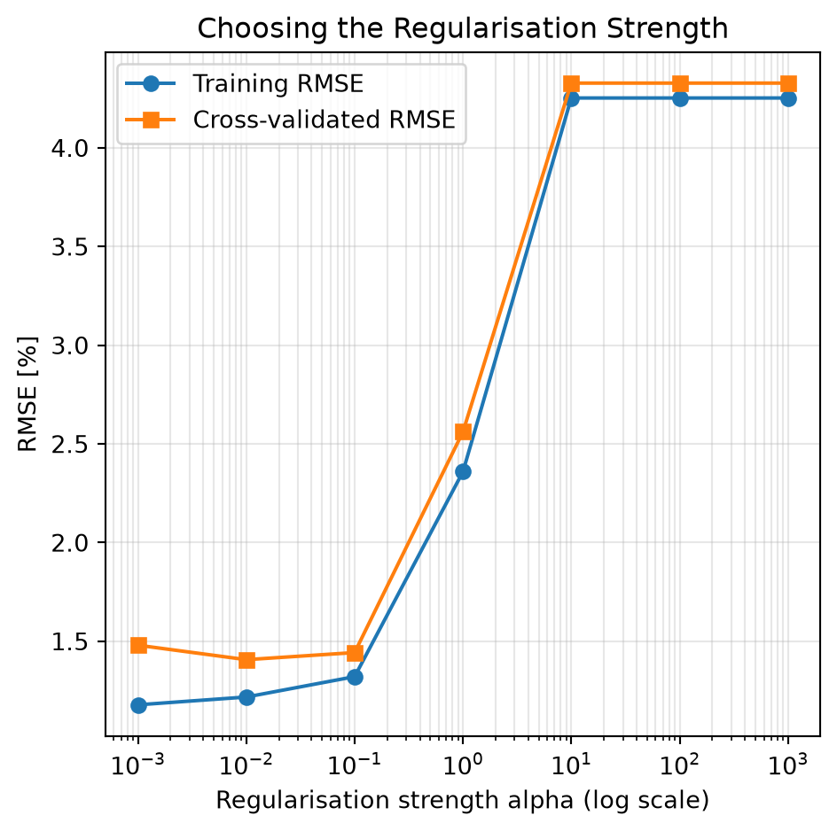

Output

```
Best alpha by cross-validation: 0.01
```

### Task 16 : Compare the regularised and unregularised models

Evaluate the lasso model using the selected value of $\alpha$. Fit the model to the reduced training set, assess its performance on the test set using `evaluate_regression`, and compare the results with those obtained from the unregularised and ridge-regression models.

lasso_model = build_lasso_model(degree=6, alpha=best_alpha).fit(X_small, y_small)

lasso_metrics = evaluate_regression(lasso_model, X_test, y_test)

MAE: 1.817

MSE: 5.566

RMSE: 2.359

R2: 0.423

**Callout-answer**Answer**

```
build_lasso_model.py
```

```python
def build_lasso_model(degree, alpha):
    """
    Build an unfitted polynomial Lasso (L1) regression pipeline.

    Parameters
    ----------
    degree : int
        The highest power of the feature to include.
    alpha : float
        The regularisation strength.

    Returns
    -------
    model : Pipeline
        An unfitted pipeline of PolynomialFeatures, StandardScaler and Lasso.
    """
    model = make_pipeline(
        PolynomialFeatures(degree=degree, include_bias=False),
        StandardScaler(),
        Lasso(alpha=alpha, max_iter=500000),
    )
    return model

lasso_model = build_lasso_model(degree=6, alpha=0.01).fit(X_small, y_small)
lasso_metrics = evaluate_regression(lasso_model, X_test, y_test)
```

Output

```
MAE:  1.817
MSE:  5.566
RMSE: 2.359
R2:   0.423
```

Also write a small helper `report_active_terms` that prints each polynomial power alongside its fitted coefficient and flags the ones that were driven to zero. Fit a degree-6 Lasso model with `alpha=0.01` to the 20-run training set, score it on the test set, and report which terms survived. Then run the same helper on the degree-6 ridge model from Part C and compare the counts.

print("Ridge model (from Part C):")

Ridge model (from Part C):

report_active_terms(final_model)

Active terms: 6 of 6

R : +6.4004 (kept)

R^2 : +0.7926 (kept)

R^3 : -1.8170 (kept)

R^4 : -1.9087 (kept)

R^5 : -0.8299 (kept)

R^6 : +0.5654 (kept)

np.int64(6)

print("Lasso model:")

Lasso model:

report_active_terms(lasso_model)

Active terms: 2 of 6

R : +7.3905 (kept)

R^2 : -0.0000 (dropped)

R^3 : -4.0978 (kept)

R^4 : -0.0000 (dropped)

R^5 : -0.0000 (dropped)

R^6 : +0.0000 (dropped)

np.int64(2)

**NoteWhat Lasso does differently**

Lasso swaps ridge’s sum of *squared* coefficients for the sum of their *absolute* values, $\alpha \sum_j |w_j|$, known as the **L1 penalty**. L1 pushes coefficients to *exactly* zero and leaves them there. A term with a zero coefficient is removed from the model, so Lasso performs **feature selection** and regularisation in a single step.

**Callout-answer**Answer**

```
report_active_terms.py
```

```python
def report_active_terms(model):
    """
    Print each polynomial term with its coefficient and flag the ones set to zero.

    Parameters
    ----------
    model : fitted Pipeline
        A polynomial regression pipeline whose final step exposes `.coef_`.

    Returns
    -------
    active : int
        The number of terms with a nonzero coefficient.
    """
    # The power labels live on the first step; the coefficients on the last
    names = model[0].get_feature_names_out(["R"])
    coefficients = model[-1].coef_

    active = np.sum(np.abs(coefficients) > 1e-8)
    print(f"Active terms: {active} of {len(coefficients)}")
    for name, coef in zip(names, coefficients):
        status = "kept" if abs(coef) > 1e-8 else "dropped"
        print(f"  {name:5s}: {coef:+9.4f}  ({status})")
    return active

print("Ridge model (from Part C):")
report_active_terms(final_model)
print("Lasso model:")
report_active_terms(lasso_model)
```

Output

```
Ridge model (from Part C):
Active terms: 6 of 6
  R    :   +6.4004  (kept)
  R^2  :   +0.7926  (kept)
  R^3  :   -1.8170  (kept)
  R^4  :   -1.9087  (kept)
  R^5  :   -0.8299  (kept)
  R^6  :   +0.5654  (kept)
Lasso model:
Active terms: 2 of 6
  R    :   +7.3905  (kept)
  R^2  :   -0.0000  (dropped)
  R^3  :   -4.0978  (kept)
  R^4  :   -0.0000  (dropped)
  R^5  :   -0.0000  (dropped)
  R^6  :   +0.0000  (dropped)
```

Output

```
np.int64(2)
```

Reuse the `plot_coefficients` function developed in the previous task to compare the coefficients of the **unregularised polynomial model**, the **ridge-regularised model**, and the **lasso-regularised model**. Use the resulting plot to examine how the L1 and L2 penalties affect the coefficient values and identify any coefficients that have been reduced exactly to zero by the lasso penalty.

plot_coefficients({"No penalty": small_poly,"Ridge": final_model,"Lasso": lasso_model},

title="Comparison of Regularisation Methods")

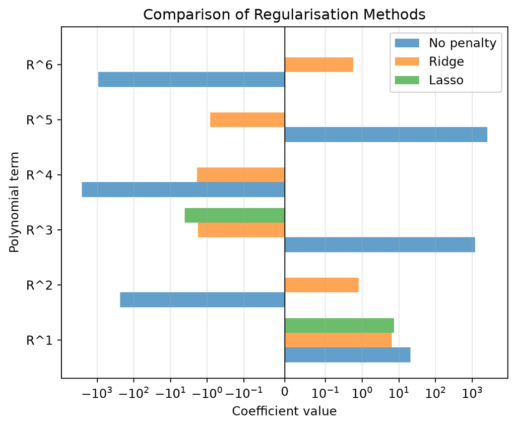

### Task 17 : Blend both penalties with Elastic Net

**NoteWhat Elastic Net Regression Does**

Ordinary least squares chooses the coefficients that minimise only the sum of squared errors. Elastic Net minimises the error plus a weighted combination of both penalties:

$$\text{minimise} \quad
\sum_{i=1}^{n}\left(y_i-\hat{y}_i\right)^2
+
\alpha \left[
(1-\lambda)\sum_{j=1}^{d} w_j^2
+
\lambda\sum_{j=1}^{d}|w_j|
\right]$$

The penalty contains both an **L2 penalty** (ridge) and an **L1 penalty** (lasso). As a result, Elastic Net balances three competing objectives:

1. fitting the training data accurately,
2. keeping the coefficients small, and
3. removing unnecessary terms from the model.

The hyperparameter $\alpha$ controls the overall strength of the regularisation, while $\lambda$ (called `l1_ratio` in scikit-learn) controls the mix of L1 and L2 penalties:

- `l1_ratio = 0` gives ridge regression,
- `l1_ratio = 1` gives lasso regression,
- values between 0 and 1 produce a combination of both.

Like ridge regression, Elastic Net shrinks coefficient magnitudes towards zero. Like lasso regression, it can also shrink some coefficients **exactly to zero**, effectively removing those terms from the model.

As with ridge and lasso regression, the intercept ($w_0$) is not penalised. Penalising the intercept would simply shift all predictions towards zero, which is usually undesirable.

Write a function `build_elastic_net_model` that takes a degree, an `alpha` and an `l1_ratio`, and returns the pipeline with `ElasticNet` as its final step.

**NoteThe mixing parameter `l1_ratio`**

Why bother mixing? Pure Lasso struggles when features are strongly correlated, and the powers of a single variable are about as correlated as features get. Faced with a group of near-identical columns, Lasso tends to keep one at random and zero the rest, which makes the exact selection unstable from one dataset to the next. The ridge part of the penalty spreads weight more evenly across a correlated group, so Elastic Net keeps Lasso’s ability to drop terms while being steadier about *which* it drops. Here Elastic Net retains more terms than Lasso but fewer than or equal to Ridge, combining coefficient shrinkage with feature selection.

```
build_elastic_net_model.py
```

```python
def build_elastic_net_model(degree, alpha, l1_ratio):
    """
    Build an unfitted polynomial Elastic Net regression pipeline.

    Parameters
    ----------
    degree : int
        The highest power of the feature to include.
    alpha : float
        The overall regularisation strength.
    l1_ratio : float
        The balance between L1 and L2 (0 is pure ridge, 1 is pure Lasso).

    Returns
    -------
    model : Pipeline
        An unfitted pipeline of PolynomialFeatures, StandardScaler and ElasticNet.
    """
```

After defining `build_elastic_net_model`, use it to fit Elastic Net models with different values of $\alpha$. For simplicity, set `l1_ratio = 0.5`, giving equal weight to the L1 (lasso) and L2 (ridge) penalties. Then reuse the `plot_fitted_curves` function developed earlier to compare the resulting fits. When you run `plot_fitted_curves`, it should yield the following output:

l1_ratio=0.5

alpha_models = {"No penalty": small_poly}

for alpha in [0.01, 1.0, 1000.0]:

alpha_models[f"alpha = {alpha}"] = build_elastic_net_model(6, alpha, l1_ratio).fit(X_small, y_small)

plot_fitted_curves(alpha_models, X_small, y_small,

"Effect of the Elastic Net Penalty (Degree 6)")

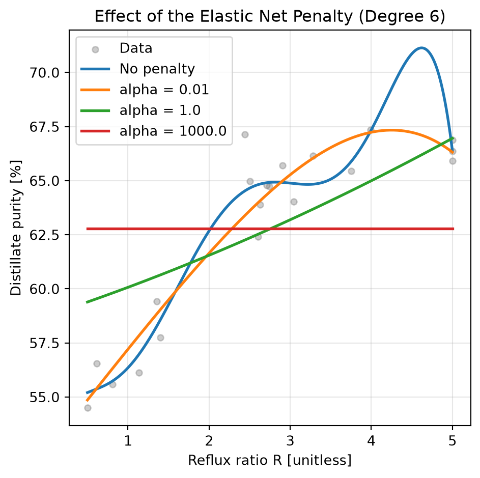

### Task: 18 Choose Alpha by Cross-Validation

Next, write a function `plot_alpha_sweep_elastic_net` that evaluates a degree-6 **Elastic Net** model over a range of $\alpha$ values. For each value, record the training RMSE and the 5-fold cross-validated RMSE, then plot both against $\alpha$ on a logarithmic scale. As in the previous task, use `l1_ratio = 0.5`, which gives equal weight to the L1 (lasso) and L2 (ridge) penalties. Then, use the cross-validation results to select an appropriate value of $\alpha$.

**TipHint**

Reuse the workflow from `plot_alpha_sweep_lasso`. Replace `build_lasso_model` with `build_elastic_net_model`, passing `l1_ratio=0.5`, and remember to convert the negative RMSE values returned by `cross_val_score()` back to positive RMSE values.

l1_ratio= 0.5

alphas = np.logspace(-3, 3, 7)

cv_rmse = plot_alpha_sweep_elastic_net(X_small, y_small, degree=6, alphas=alphas,l1_ratio=l1_ratio)

alpha = 0.001: train RMSE = 1.197 CV RMSE = 1.420

alpha = 0.010: train RMSE = 1.241 CV RMSE = 1.403

alpha = 0.100: train RMSE = 1.442 CV RMSE = 1.523

alpha = 1.000: train RMSE = 2.645 CV RMSE = 2.822

alpha = 10.000: train RMSE = 4.253 CV RMSE = 4.328

alpha = 100.000: train RMSE = 4.253 CV RMSE = 4.328

alpha = 1000.000: train RMSE = 4.253 CV RMSE = 4.328

best_alpha = alphas[np.argmin(cv_rmse)]

print(f"Best alpha by cross-validation: {best_alpha}")

Best alpha by cross-validation: 0.01

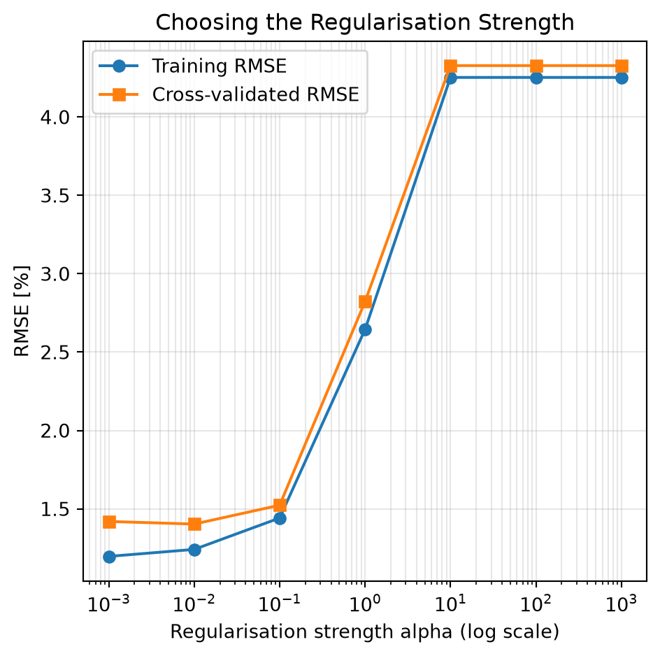

**Callout-answer**Answer**

```
plot_alpha_sweep_elastic_net.py
```

```python
def plot_alpha_sweep_elastic_net(X_train, y_train, degree, alphas, l1_ratio):
    """
    Plot training and cross-validated RMSE as a function
    of the elastic net regularisation strength, alpha.

    Parameters
    ----------
    X_train : pd.DataFrame
        Training features.
    y_train : pd.Series
        Training targets.
    degree : int
        Polynomial degree used in the elastic net model.
    alphas : array-like
        Sequence of alpha values to evaluate.

    Returns
    -------
    cv_rmse : list
        Mean cross-validated RMSE for each alpha value.
    """
    train_rmse, cv_rmse = [], []

    for alpha in alphas:
        # Build an elastic net model with the current alpha
        model = build_elastic_net_model(degree, alpha, l1_ratio)

        # Estimate performance using 5-fold cross-validation
        scores = cross_val_score(model, X_train, y_train, cv=5,
                                 scoring="neg_root_mean_squared_error")
        cv_rmse.append(-scores.mean())

        # Fit the model to the full training set and calculate the training RMSE
        model.fit(X_train, y_train)
        train_rmse.append(np.sqrt(mean_squared_error(y_train, model.predict(X_train))))

        print(f"  alpha = {alpha:8.3f}:  train RMSE = {train_rmse[-1]:.3f}   CV RMSE = {cv_rmse[-1]:.3f}")

    # Plot training and cross-validation error
    plt.figure(figsize=(5, 5))
    plt.plot(alphas, train_rmse, "o-", label="Training RMSE")
    plt.plot(alphas, cv_rmse, "s-", label="Cross-validated RMSE")
    plt.xscale("log")
    plt.xlabel("Regularisation strength alpha (log scale)")
    plt.ylabel("RMSE [%]")
    plt.title("Choosing the Regularisation Strength")
    plt.legend()
    plt.grid(True, alpha=0.3, which="both")
    plt.tight_layout()
    plt.show()
    return cv_rmse

l1_ratio= 0.5
alphas = np.logspace(-3, 3, 7)
cv_rmse = plot_alpha_sweep_elastic_net(X_small, y_small, degree=6, alphas=alphas,l1_ratio=l1_ratio)
best_alpha = alphas[np.argmin(cv_rmse)]
print(f"Best alpha by cross-validation: {best_alpha}")
```

Output

```
  alpha =    0.001:  train RMSE = 1.197   CV RMSE = 1.420
  alpha =    0.010:  train RMSE = 1.241   CV RMSE = 1.403
  alpha =    0.100:  train RMSE = 1.442   CV RMSE = 1.523
  alpha =    1.000:  train RMSE = 2.645   CV RMSE = 2.822
  alpha =   10.000:  train RMSE = 4.253   CV RMSE = 4.328
  alpha =  100.000:  train RMSE = 4.253   CV RMSE = 4.328
  alpha = 1000.000:  train RMSE = 4.253   CV RMSE = 4.328
```

Output

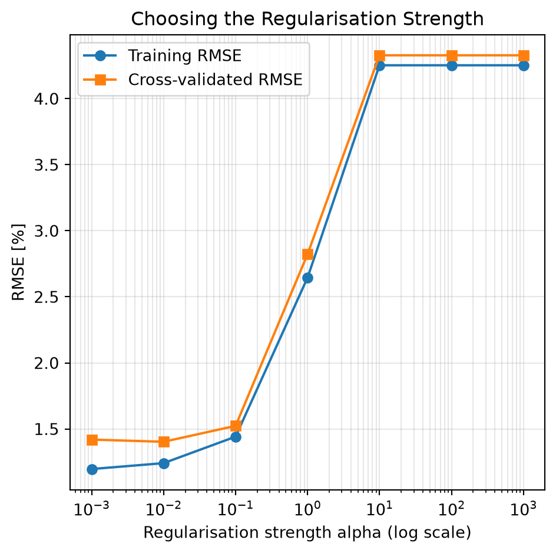

Output

```
Best alpha by cross-validation: 0.01
```

### Task 19 : Compare the regularised and unregularised models

Evaluate the Elastic Net model using the selected value of $\alpha$ and `l1_ratio = 0.5`. Fit the model to the reduced training set, assess its performance on the test set using `evaluate_regression`, and compare the results with those obtained from the unregularised, ridge-regression, and lasso-regression models.

elastic_model = build_elastic_net_model(degree=6, alpha=best_alpha, l1_ratio=0.5).fit(X_small, y_small)

elastic_metrics = evaluate_regression(elastic_model, X_test, y_test)

MAE: 1.790

MSE: 5.518

RMSE: 2.349

R2: 0.428

Reuse the `report_active_terms` function developed in the previous task to identify which polynomial terms remain active in the Elastic Net model. Compare the result with the lasso model and examine which coefficients have been reduced exactly to zero and which have been retained.

print("Elastic Net model:")

Elastic Net model:

report_active_terms(elastic_model)

Active terms: 5 of 6

R : +6.5542 (kept)

R^2 : +0.0365 (kept)

R^3 : -1.1900 (kept)

R^4 : -1.6094 (kept)

R^5 : -0.5948 (kept)

R^6 : -0.0000 (dropped)

np.int64(5)

Reuse the `plot_coefficients` function developed in the ridge regression task to compare the coefficients of the **unregularised polynomial model**, the **ridge-regularised model**, the **lasso-regularised model**, and the **Elastic Net model**.

plot_coefficients({"No penalty": small_poly,"Ridge": final_model,"Lasso": lasso_model,"Elastic Net": elastic_model,},

title="Comparison of Regularisation Methods")

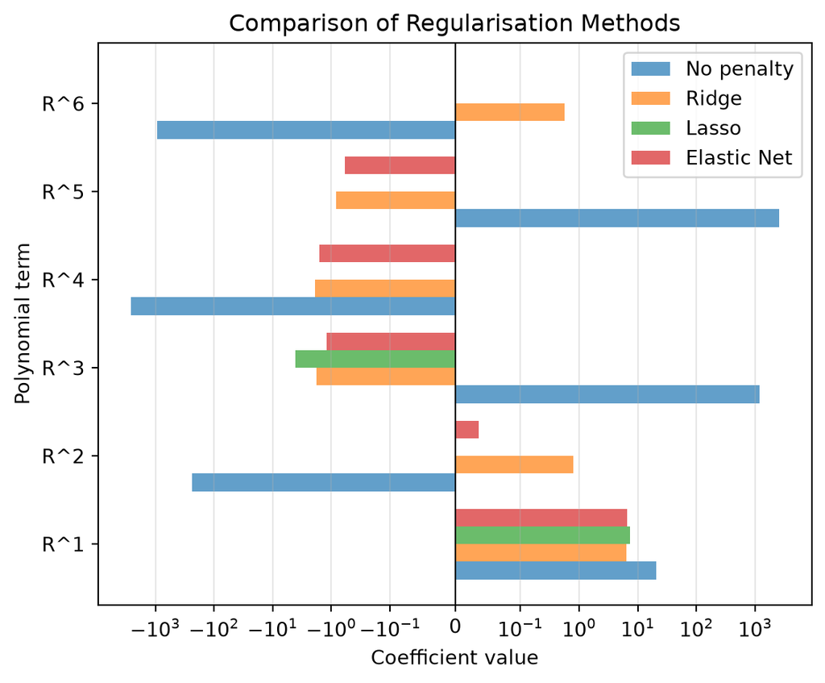

Reuse the `plot_fitted_curves` function developed earlier to compare the fitted curves produced by the regularised models. Create a dictionary of fitted models and use it to visualise how ridge, lasso, and Elastic Net balance model flexibility and smoothness.

penalty_models = {

"Ridge (6 terms)": final_model,

"Lasso (2 terms)": lasso_model,

"Elastic Net (5 terms)": elastic_model,

}

plot_fitted_curves(penalty_models, X_small, y_small, "Three Penalties, One Curve")

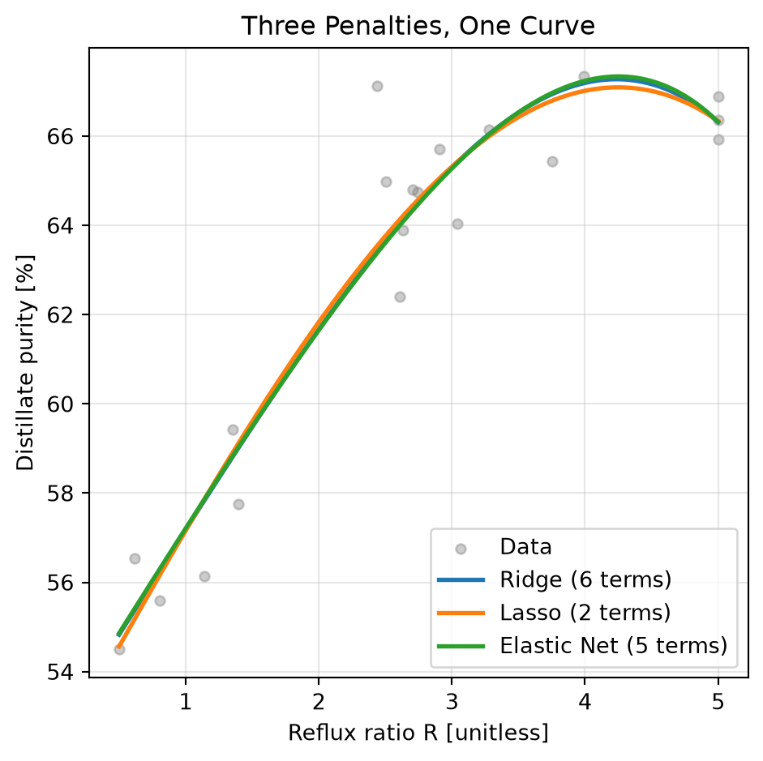

**Same curve, very different models.** The three fitted curves lie almost on top of one another and achieve similar R² values on the test set. Despite this, the underlying models differ substantially in complexity: one uses all six polynomial terms, one retains five terms, and one uses only two.

This highlights an important principle in machine learning: when several models provide similar predictive performance, the simplest model is often preferred. Simpler models are easier to interpret, less likely to be fitting noise in the training data, and are generally more robust when applied to new data. **Regularisation** is therefore not only a tool for improving predictive performance, but also a **tool for identifying the simplest model** that adequately describes the data.

**Callout-answer**Answer**

```
build_elastic_net_model.py
```

```python
def build_elastic_net_model(degree, alpha, l1_ratio):
    """
    Build an unfitted polynomial Elastic Net regression pipeline.

    Parameters
    ----------
    degree : int
        The highest power of the feature to include.
    alpha : float
        The overall regularisation strength.
    l1_ratio : float
        The balance between L1 and L2 (0 is pure ridge, 1 is pure Lasso).

    Returns
    -------
    model : Pipeline
        An unfitted pipeline of PolynomialFeatures, StandardScaler and ElasticNet.
    """
    model = make_pipeline(
        PolynomialFeatures(degree=degree, include_bias=False),
        StandardScaler(),
        ElasticNet(alpha=alpha, l1_ratio=l1_ratio, max_iter=500000),
    )
    return model

# plot_fitted_curves takes any dictionary of fitted models, so it works unchanged.
penalty_models = {
    "Ridge (6 terms)": final_model,
    "Lasso (2 terms)": lasso_model,
    "Elastic Net (5 terms)": elastic_model,
}
plot_fitted_curves(penalty_models, X_small, y_small, "Three Penalties, One Curve")
```

Output

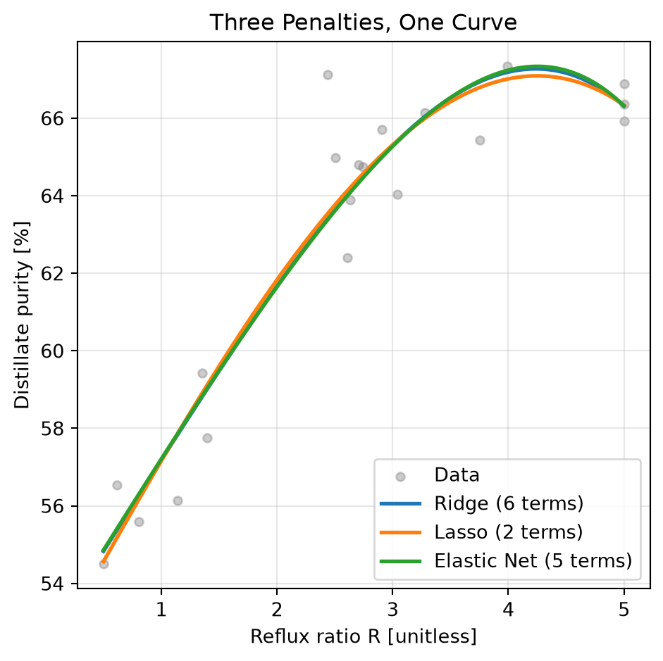

## Conclusion

In this tutorial you fitted **curves** instead of straight lines, and then learned how to stop them from curving too much. Polynomial regression turned out to need no new algorithm at all: raise the feature to a set of powers, hand the resulting columns to the same least-squares fit as last week, and wrap the whole thing in a **pipeline** so the transformation travels with the model.

**Ridge regression** turned the complexity setting from a discrete choice into a continuous one. Rather than deciding which terms a model may have, you let it keep them all and charge it for using them, then tune the price by cross-validation.

Finally the penalty type matters as much as its magnitude. **Lasso** replaces ridge’s squared penalty with an absolute one and, as a result, drives coefficients to exactly zero, selecting features while it regularises. **Elastic Net** blends the two so it can drop terms without being thrown off by correlated features.

## Sources

- [Scikit-learn documentation](https://scikit-learn.org/stable/documentation.html)
- [Polynomial features](https://scikit-learn.org/stable/modules/linear_model.html#polynomial-regression-extending-linear-models-with-basis-functions)
- [Ridge regression](https://scikit-learn.org/stable/modules/linear_model.html#ridge-regression-and-classification)
- [Lasso](https://scikit-learn.org/stable/modules/linear_model.html#lasso)
- [Elastic Net](https://scikit-learn.org/stable/modules/linear_model.html#elastic-net)
- [Pipelines](https://scikit-learn.org/stable/modules/compose.html#pipeline-chaining-estimators)
- [Underfitting vs overfitting](https://scikit-learn.org/stable/auto_examples/model_selection/plot_underfitting_overfitting.html)